# Serie de tiempo cáncer de pulmón en Antofagasta

#### Variables en la base de datos.

- TUMOURID: Identificación del tumor.
- NOCASO: Número del caso (1 caso puede tener uno o más tumores).
- FECNAC: Fecha nacimiento en formato YYYYMMDD (variable numérica).
- EDAD: Edad en años a la fecha del diagnóstico.
- SEXO:
  - 1=Hombre,
  - 2=Mujeres.
- REGCOM: Código comunas:
  - 2101=Antofagasta;
  - 2201=Calama;
  - 2301=Tocopilla.
- FECDIAG: Fecha de diagnóstico del tumor en formato YYYYMMDD (variable numérica), “20030101 - 20151231”.
- TOP: Código topográfico del tumor en formato CIE-O.
- MORF: Código morfológico CIE-O.
- MORF_GRUPO (PULMON):
  - 1=Neoplasias, SAI;
  - 2=Neoplasias Epiteliales, SAI;
  - 3=Neoplasias de Células escamosas;
  - 4=Adenocarcinomas;
  - 5=Otras Morfologías
- COMP: Comportamiento del tumor:
  - 3=Maligno.
- GRA: Grado de diferenciación del tumor:
  - 1=Bien diferenciado;
  - 2= Moderadamente Diferenciado;
  - 3=Poco Diferenciado;
  - 4=Anaplásico;
  - 5=Células T;
  - 6=Células B;
  - 7=Célula Nula;
  - 8=Células NK;
  - 9=Desconocido.
- EXT: Grado de extensión del tumor:
  - 0=In situ;
  - 1=Localizado;
  - 2=Regional;
  - 3=Metástasis;
  - 9=Desconocido.
- BASE: Base diagnóstico:
  - 0=Solo Certificado de defunción;
  - 1=Clínico;
  - 2=Investigación clínica;
  - 4=Bioquímica o Inmunología;
  - 5=Citología;
  - 6=Histología de metástasis;
  - 7=Histología de sitio primario;
  - 9=Desconocido.
- C10: Código CIE10.
- PMSEC: Secuencia de tumores primarios.
- PMTOT: Número total de tumores primarios.
- FUE1: Fuente.
- RUT: Rut del caso.

# Estadística descriptiva

## Univariada categórica para tumores de Pulmón

### Número de casos por sexo

```
##
## Hombres Mujeres
##    1554     670
```

### Proporción de casos por sexo

```
##
## Hombres Mujeres
##   69.87   30.13
```

### Casos por comuna

```
##
##                 Afta           Mejillones         Sierra Gorda
##                 1725                   38                    5
##               Taltal               Calama              Ollagüe
##                   57                  213                    0
## San Pedro de Atacama            Tocopilla          MAría Elena
##                    8                  156                   22
##                  Sum
##                 2224
```

### Proporción de casos por comuna

```
##
##                 Afta           Mejillones         Sierra Gorda
##                   78                    2                    0
##               Taltal               Calama              Ollagüe
##                    3                   10                    0
## San Pedro de Atacama            Tocopilla          MAría Elena
##                    0                    7                    1
```

### Casos en Antofagasta, Calama y Tocopilla

```
##
##      Afta    Calama Tocopilla
##      1725       213       156
```

### Proporción de casos en Antofagasta, Calama y Tocopilla

```
##
##      Afta    Calama Tocopilla
##     82.38     10.17      7.45
```

### Casos según morfología

```
##
##                 Neoplasias, SAI     Neoplasias Epiteliales, SAI
##                            1085                             413
## Neoplasias de células escamosas                 Adenocarcinomas
##                             510                             193
##               Otras morfologías
##                              21
```

### Proporción de casos según morfología

```
##
##                 Neoplasias, SAI     Neoplasias Epiteliales, SAI
##                            48.8                            18.6
## Neoplasias de células escamosas                 Adenocarcinomas
##                            23.0                             8.7
##               Otras morfologías
##                             0.9
```

### Casos según diferenciacion tumores

```
##
##           Bien Diferenciado Moderadamente Diferenciados
##                          28                         355
##           Poco Diferenciado                  Anaplásico
##                         376                          54
##                 Desconocido
##                        1411
```

### Proporción de casos según diferenciación

```
##
##           Bien Diferenciado Moderadamente Diferenciados
##                        1.26                       15.96
##           Poco Diferenciado                  Anaplásico
##                       16.91                        2.43
##                 Desconocido
##                       63.44
```

### Casos según extensión tumoral

```
##
##  Localizado    Regional  Metástasis Desconocido
##         870         259         610         485
```

### Proporción de casos según extensión tumoral

```
##
##  Localizado    Regional  Metástasis Desconocido
##       39.12       11.65       27.43       21.81
```

### Casos según base diagnóstico

```
##
##                     Solo DCO                      Clínica
##                          403                          105
##        Investigación Clínica                    Citología
##                          548                            1
##            Histología de MTS Histología de sitio primario
##                          104                         1063
```

### Proporción de casos según base diagnóstico

```
##
##                     Solo DCO                      Clínica
##                        18.12                         4.72
##        Investigación Clínica                    Citología
##                        24.64                         0.04
##            Histología de MTS Histología de sitio primario
##                         4.68                        47.80
```

## Estadística descriptiva univariada cuantitativa, Pulmón

### Edad

| Mínimo | Máximo | Rango | Qu_25 | Qu_50 | Qu_75 | Media | Mediana | Varianza | Desv_Estándar | CV |
| --- | --- | --- | --- | --- | --- | --- | --- | --- | --- | --- |
| 19 | 95 | 76 | 60 | 67 | 75 | 66.9982 | 67 | 114.7755 | 10.7133 | 15.9905 |

### Histrograma edad

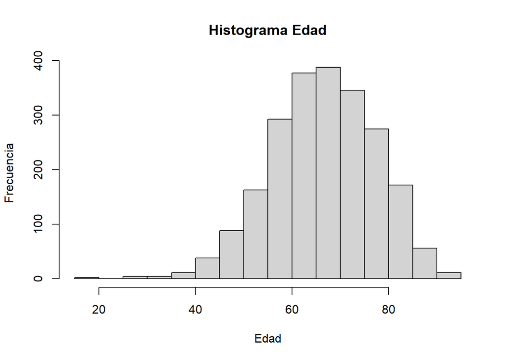

### Gráfico de densidad edad

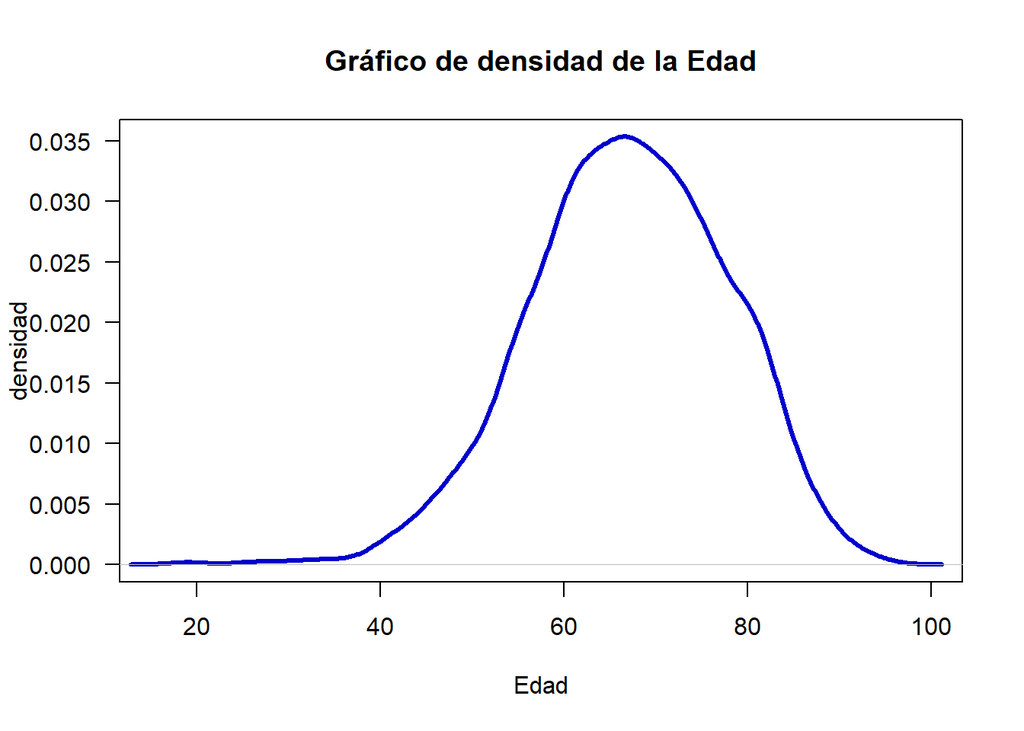

### Normal QQ

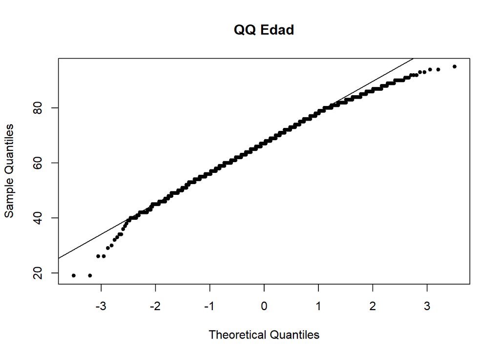

### Test de normalidad de Shapiro-Wilk

```
##
##  Shapiro-Wilk normality test
##
## data:  bd_pulmon$EDAD
## W = 0.99233, p-value = 2.006e-09
```

## Estadística descriptiva Bivariada

### Número de casos por sexo en las comunas de Antofagasta, Calama y Tocopilla

```
##
##               Hombres Mujeres  Sum
##   Antofagasta    1179     546 1725
##   Calama          157      56  213
##   Tocopilla       119      37  156
##   Sum            1455     639 2094
```

### Proporción de casos por sexo en las comunas de Antofagasta, Calama y Tocopilla

```
##
##               Hombres Mujeres    Sum
##   Antofagasta   68.35   31.65 100.00
##   Calama        73.71   26.29 100.00
##   Tocopilla     76.28   23.72 100.00
```

### Número de casos por sexo y morfología

```
##
##                                   Hombres Mujeres  Sum
##   Neoplasias, SAI                     739     346 1085
##   Neoplasias Epiteliales, SAI         294     119  413
##   Neoplasias de células escamosas     383     127  510
##   Adenocarcinomas                     122      71  193
##   Otras morfologías                    14       7   21
##   Sum                                1552     670 2222
```

### Proporción de casos por sexo y morfología

```
##
##                                   Hombres Mujeres    Sum
##   Neoplasias, SAI                   68.11   31.89 100.00
##   Neoplasias Epiteliales, SAI       71.19   28.81 100.00
##   Neoplasias de células escamosas   75.10   24.90 100.00
##   Adenocarcinomas                   63.21   36.79 100.00
##   Otras morfologías                 66.67   33.33 100.00
```

### Número de casos por sexo y extensión tumoral

```
##
##               Hombres Mujeres  Sum
##   Localizado      607     263  870
##   Regional        174      85  259
##   Metástasis      432     178  610
##   Desconocido     341     144  485
##   Sum            1554     670 2224
```

### Proporción de casos por sexo y extensión tumoral

```
##
##               Hombres Mujeres    Sum
##   Localizado    69.77   30.23 100.00
##   Regional      67.18   32.82 100.00
##   Metástasis    70.82   29.18 100.00
##   Desconocido   70.31   29.69 100.00
```

### Número de casos por sexo y base diagnóstica

```
##
##                                Hombres Mujeres  Sum
##   Solo DCO                         290     113  403
##   Clínico                           68      37  105
##   Investigación Clínica            365     183  548
##   Citología                          0       1    1
##   Histología de Metástasis          69      35  104
##   Histología de sitio primario     762     301 1063
##   Sum                             1554     670 2224
```

### Proporción de casos por sexo y base diagnóstica

```
##
##                                Hombres Mujeres    Sum
##   Solo DCO                       71.96   28.04 100.00
##   Clínico                        64.76   35.24 100.00
##   Investigación Clínica          66.61   33.39 100.00
##   Citología                       0.00  100.00 100.00
##   Histología de Metástasis       66.35   33.65 100.00
##   Histología de sitio primario   71.68   28.32 100.00
```

### Número de casos por Morfología y base diagnóstica

```
##
##                                   Solo DCO Clínico Investigación Clínica
##   Neoplasias, SAI                      403     105                   548
##   Neoplasias Epiteliales, SAI            0       0                     0
##   Neoplasias de células escamosas        0       0                     0
##   Adenocarcinomas                        0       0                     0
##   Otras morfologías                      0       0                     0
##   Sum                                  403     105                   548
##
##                                   Citología Histología de Metástasis
##   Neoplasias, SAI                         1                        3
##   Neoplasias Epiteliales, SAI             0                       44
##   Neoplasias de células escamosas         0                       23
##   Adenocarcinomas                         0                       32
##   Otras morfologías                       0                        2
##   Sum                                     1                      104
##
##                                   Histología de sitio primario  Sum
##   Neoplasias, SAI                                           25 1085
##   Neoplasias Epiteliales, SAI                              369  413
##   Neoplasias de células escamosas                          487  510
##   Adenocarcinomas                                          161  193
##   Otras morfologías                                         19   21
##   Sum                                                     1061 2222
```

### Proporción de casos por Morfología y base diagnóstica

```
##
##                                   Solo DCO Clínico Investigación Clínica
##   Neoplasias, SAI                    37.14    9.68                 50.51
##   Neoplasias Epiteliales, SAI         0.00    0.00                  0.00
##   Neoplasias de células escamosas     0.00    0.00                  0.00
##   Adenocarcinomas                     0.00    0.00                  0.00
##   Otras morfologías                   0.00    0.00                  0.00
##
##                                   Citología Histología de Metástasis
##   Neoplasias, SAI                      0.09                     0.28
##   Neoplasias Epiteliales, SAI          0.00                    10.65
##   Neoplasias de células escamosas      0.00                     4.51
##   Adenocarcinomas                      0.00                    16.58
##   Otras morfologías                    0.00                     9.52
##
##                                   Histología de sitio primario    Sum
##   Neoplasias, SAI                                         2.30 100.00
##   Neoplasias Epiteliales, SAI                            89.35 100.00
##   Neoplasias de células escamosas                        95.49 100.00
##   Adenocarcinomas                                        83.42 100.00
##   Otras morfologías                                      90.48 100.00
```

### Número de casos por Morfología y Extensión

```
##
##                                   Localizado Regional Metástasis Desconocido
##   Neoplasias, SAI                        149      105        377         454
##   Neoplasias Epiteliales, SAI            255       56         91          11
##   Neoplasias de células escamosas        355       58         82          15
##   Adenocarcinomas                        102       34         52           5
##   Otras morfologías                        8        6          7           0
##   Sum                                    869      259        609         485
##
##                                    Sum
##   Neoplasias, SAI                 1085
##   Neoplasias Epiteliales, SAI      413
##   Neoplasias de células escamosas  510
##   Adenocarcinomas                  193
##   Otras morfologías                 21
##   Sum                             2222
```

### Proporción de casos por Morfología y Extensión

```
##
##                                   Localizado Regional Metástasis Desconocido
##   Neoplasias, SAI                      13.73     9.68      34.75       41.84
##   Neoplasias Epiteliales, SAI          61.74    13.56      22.03        2.66
##   Neoplasias de células escamosas      69.61    11.37      16.08        2.94
##   Adenocarcinomas                      52.85    17.62      26.94        2.59
##   Otras morfologías                    38.10    28.57      33.33        0.00
##
##                                      Sum
##   Neoplasias, SAI                 100.00
##   Neoplasias Epiteliales, SAI     100.00
##   Neoplasias de células escamosas 100.00
##   Adenocarcinomas                 100.00
##   Otras morfologías               100.00
```

### Número de casos por Morfología y comuna

```
##
##                                   Antofagasta Calama Tocopilla  Sum
##   Neoplasias, SAI                         798    124        87 1009
##   Neoplasias Epiteliales, SAI             331     32        30  393
##   Neoplasias de células escamosas         428     30        26  484
##   Adenocarcinomas                         149     25        13  187
##   Otras morfologías                        18      2         0   20
##   Sum                                    1724    213       156 2093
```

### Proporción de casos por Morfología y comuna, por filas

```
##
##                                   Antofagasta Calama Tocopilla    Sum
##   Neoplasias, SAI                       79.09  12.29      8.62 100.00
##   Neoplasias Epiteliales, SAI           84.22   8.14      7.63 100.00
##   Neoplasias de células escamosas       88.43   6.20      5.37 100.00
##   Adenocarcinomas                       79.68  13.37      6.95 100.00
##   Otras morfologías                     90.00  10.00      0.00 100.00
```

### Proporción de casos por Morfología y comuna, por columnas

```
##
##                                   Antofagasta Calama Tocopilla
##   Neoplasias, SAI                       46.29  58.22     55.77
##   Neoplasias Epiteliales, SAI           19.20  15.02     19.23
##   Neoplasias de células escamosas       24.83  14.08     16.67
##   Adenocarcinomas                        8.64  11.74      8.33
##   Otras morfologías                      1.04   0.94      0.00
##   Sum                                  100.00 100.00    100.00
```

### Número de casos por Extensión y comuna

```
##
##               Antofagasta Calama Tocopilla  Sum
##   Localizado          707     51        61  819
##   Regional            213     17        14  244
##   Metástasis          466     77        33  576
##   Desconocido         339     68        48  455
##   Sum                1725    213       156 2094
```

### Proporcion de casos por Extensión y comuna, filas

```
##
##               Antofagasta Calama Tocopilla    Sum
##   Localizado        86.32   6.23      7.45 100.00
##   Regional          87.30   6.97      5.74 100.00
##   Metástasis        80.90  13.37      5.73 100.00
##   Desconocido       74.51  14.95     10.55 100.00
```

### Proporción de casos por Extensión y comuna, columnas

```
##
##               Antofagasta Calama Tocopilla
##   Localizado        40.99  23.94     39.10
##   Regional          12.35   7.98      8.97
##   Metástasis        27.01  36.15     21.15
##   Desconocido       19.65  31.92     30.77
##   Sum              100.00 100.00    100.00
```

### Número de casos por Extensión y Base diagnóstica

```
##
##               Solo DCO Clínico Investigación Clínica Citología
##   Localizado         4      68                    68         0
##   Regional           3       1                    94         0
##   Metástasis        35      14                   319         1
##   Desconocido      361      22                    67         0
##   Sum              403     105                   548         1
##
##               Histología de Metástasis Histología de sitio primario  Sum
##   Localizado                        16                          714  870
##   Regional                           7                          154  259
##   Metástasis                        81                          160  610
##   Desconocido                        0                           35  485
##   Sum                              104                         1063 2224
```

### Proporción de casos por Extensión y Base diagnóstica, filas

```
##
##               Solo DCO Clínico Investigación Clínica Citología
##   Localizado      0.46    7.82                  7.82      0.00
##   Regional        1.16    0.39                 36.29      0.00
##   Metástasis      5.74    2.30                 52.30      0.16
##   Desconocido    74.43    4.54                 13.81      0.00
##
##               Histología de Metástasis Histología de sitio primario    Sum
##   Localizado                      1.84                        82.07 100.00
##   Regional                        2.70                        59.46 100.00
##   Metástasis                     13.28                        26.23 100.00
##   Desconocido                     0.00                         7.22 100.00
```

### Proporción de casos por Extensión y Base diagnóstica, columnas

```
##
##               Solo DCO Clínico Investigación Clínica Citología
##   Localizado      0.99   64.76                 12.41      0.00
##   Regional        0.74    0.95                 17.15      0.00
##   Metástasis      8.68   13.33                 58.21    100.00
##   Desconocido    89.58   20.95                 12.23      0.00
##   Sum           100.00  100.00                100.00    100.00
##
##               Histología de Metástasis Histología de sitio primario
##   Localizado                     15.38                        67.17
##   Regional                        6.73                        14.49
##   Metástasis                     77.88                        15.05
##   Desconocido                     0.00                         3.29
##   Sum                           100.00                       100.00
```

### Número de casos por Base diagnóstica y comuna

```
##
##                                Antofagasta Calama Tocopilla  Sum
##   Solo DCO                             297     53        30  380
##   Clínico                               76      7        14   97
##   Investigación Clínica                401     61        43  505
##   Citología                              1      0         0    1
##   Histología de Metástasis              80     14         4   98
##   Histología de sitio primario         870     78        65 1013
##   Sum                                 1725    213       156 2094
```

### Proporción de casos por Base diagnóstica y comuna, filas

```
##
##                                Antofagasta Calama Tocopilla    Sum
##   Solo DCO                           78.16  13.95      7.89 100.00
##   Clínico                            78.35   7.22     14.43 100.00
##   Investigación Clínica              79.41  12.08      8.51 100.00
##   Citología                         100.00   0.00      0.00 100.00
##   Histología de Metástasis           81.63  14.29      4.08 100.00
##   Histología de sitio primario       85.88   7.70      6.42 100.00
```

### Proporción de casos por Base diagnóstica y comuna, columnas

```
##
##                                Antofagasta Calama Tocopilla
##   Solo DCO                           17.22  24.88     19.23
##   Clínico                             4.41   3.29      8.97
##   Investigación Clínica              23.25  28.64     27.56
##   Citología                           0.06   0.00      0.00
##   Histología de Metástasis            4.64   6.57      2.56
##   Histología de sitio primario       50.43  36.62     41.67
##   Sum                               100.00 100.00    100.00
```

### Edad - Sexo

#### Boxplot edad vs sexo

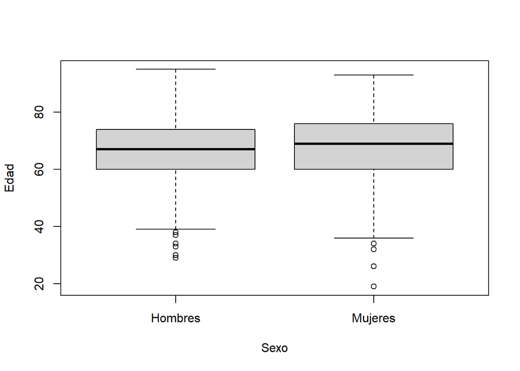

### Boxplot edad vs comuna

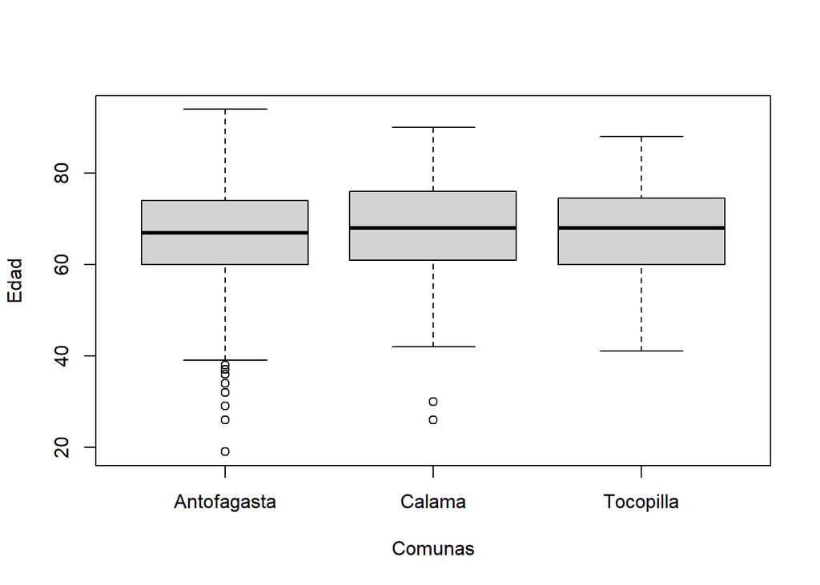

### Boxplot edad - morfologia

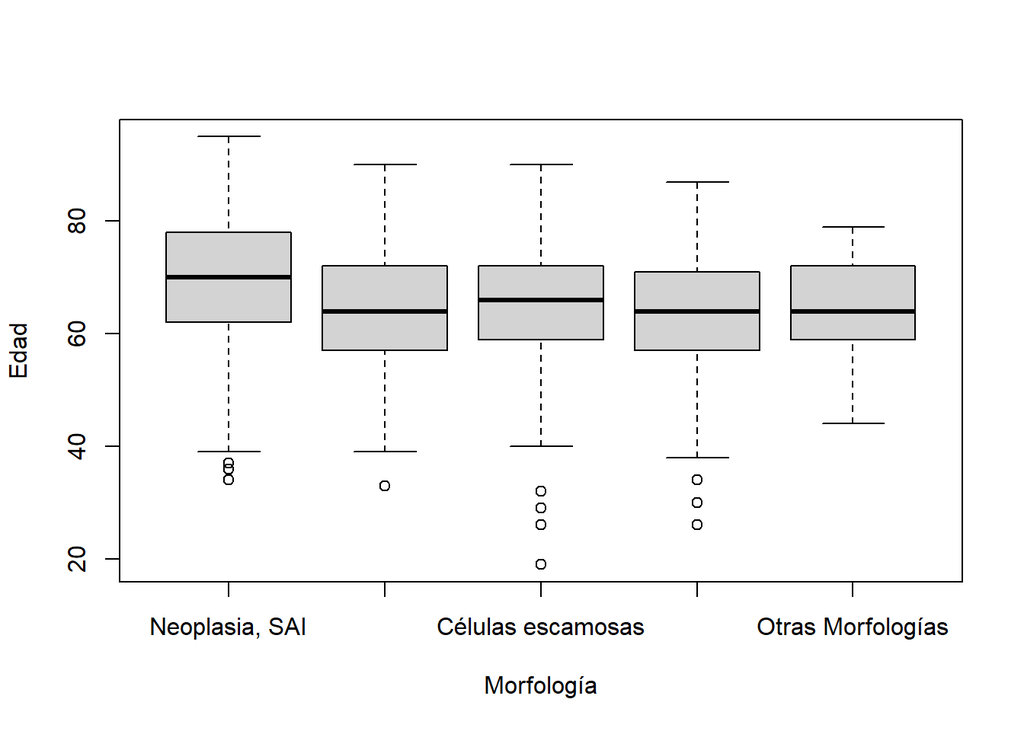

### Boxplot edad - extension

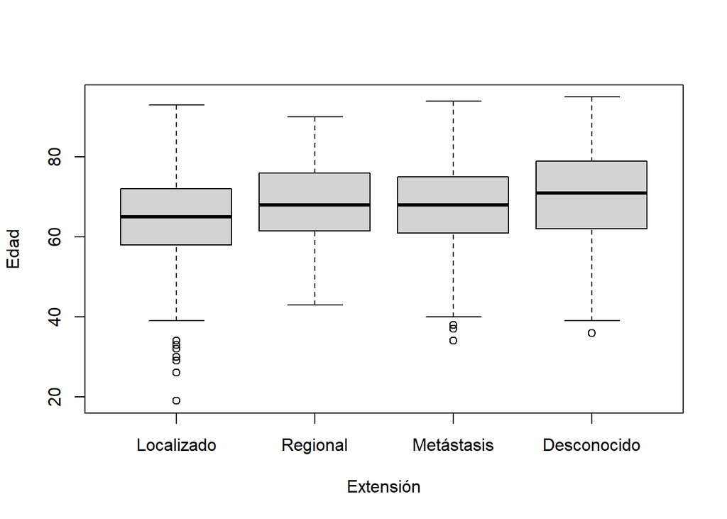

### Boxplot edad - base diagnóstica

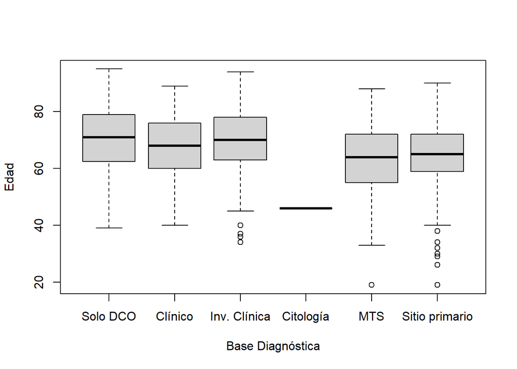

## Tasa de incidencia ajustada por edad, según año

| YEAR_DIAG | TASA_AJUSTADA |
| --- | --- |
| 2003 | 32.18200 |
| 2004 | 36.82800 |
| 2005 | 34.41583 |
| 2006 | 39.73844 |
| 2007 | 38.84144 |
| 2008 | 31.12250 |
| 2009 | 30.84151 |
| 2010 | 32.58645 |
| 2011 | 32.67251 |
| 2012 | 27.10721 |

[output cut: 3 more lines]

### Gráfico de la tasa de incidencia de cáncer de pulmón, ajustada por edad en la región de Antofagasta.

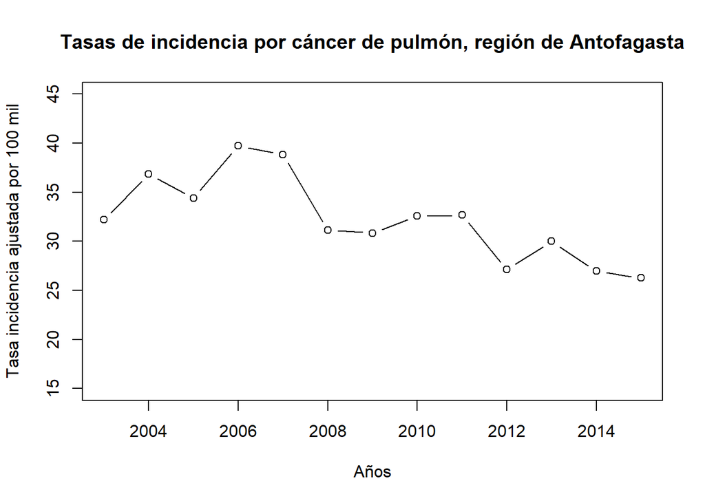

## Tasa de incidencia ajustada por edad y sexo, según año. Región de Antofagasta

| YEAR_DIAG | TASA_AJUSTADA | STD_ERROR |
| --- | --- | --- |
| 2003 | 23.27425 | 2.316436 |
| 2004 | 25.40057 | 2.458415 |
| 2005 | 25.57138 | 2.385227 |
| 2006 | 28.16758 | 2.468267 |
| 2007 | 29.19586 | 2.514429 |
| 2008 | 20.61560 | 2.053970 |
| 2009 | 21.93244 | 2.059990 |
| 2010 | 22.13975 | 2.088886 |
| 2011 | 22.86135 | 2.067129 |
| 2012 | 19.60009 | 1.892328 |

[output cut: 3 more lines]

| YEAR_DIAG | TASA_AJUSTADA | STD_ERROR |
| --- | --- | --- |
| 2003 | 8.907752 | 1.402615 |
| 2004 | 11.427430 | 1.630349 |
| 2005 | 8.844454 | 1.383694 |
| 2006 | 11.570857 | 1.598955 |
| 2007 | 9.645581 | 1.386034 |
| 2008 | 10.506906 | 1.415514 |
| 2009 | 8.909070 | 1.295212 |
| 2010 | 10.446695 | 1.408100 |
| 2011 | 9.811163 | 1.355358 |
| 2012 | 7.507113 | 1.125095 |

[output cut: 3 more lines]

### Gráfico de la tasa de incidencia de cáncer de pulmón, ajustada por edad y sexo en la región de Antofagasta.

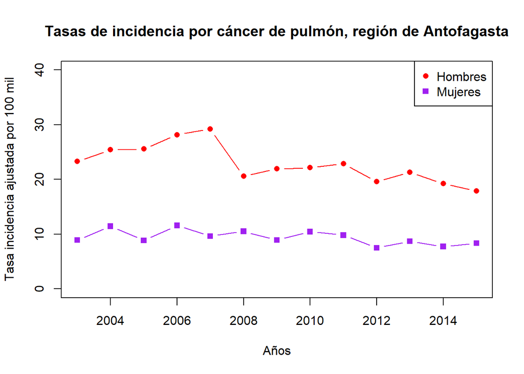

# Comuna de Antofagasta

### Número de casos por sexo, Comuna de Antofagasta

```
##
## Hombres Mujeres
##    1179     546
```

### Proporción de casos por sexo, comuna de Antofagastas

```
##
## Hombres Mujeres
##   68.35   31.65
```

### Casos según morfología, comuna de Antofagasta

```
##
##                 Neoplasias, SAI     Neoplasias Epiteliales, SAI
##                             798                             331
## Neoplasias de células escamosas                 Adenocarcinomas
##                             428                             149
##               Otras morfologías
##                              18
```

### Proporción de casos según morfología, comuna de Antofagasta

```
##
##                 Neoplasias, SAI     Neoplasias Epiteliales, SAI
##                            46.3                            19.2
## Neoplasias de células escamosas                 Adenocarcinomas
##                            24.8                             8.6
##               Otras morfologías
##                             1.0
```

### Casos según diferenciacion tumores, comuna de Antofagasta

```
##
##           Bien Diferenciado Moderadamente Diferenciados
##                          24                         301
##           Poco Diferenciado                  Anaplásico
##                         310                          43
##                 Desconocido
##                        1047
```

### Proporción de casos según diferenciación, Comuna de Antofagasta

[output not shown]

### Casos según extensión tumoral, Comuna de Antofagasta

[output not shown]

### Proporción de casos según extensión tumoral, Comuna de Antofagasta

```
##
##  Localizado    Regional  Metástasis Desconocido
##       40.99       12.35       27.01       19.65
```

### Casos según base diagnóstico, Comuna de Antofagasta

```
##
##                     Solo DCO                      Clínica
##                          297                           76
##        Investigación Clínica                    Citología
##                          401                            1
##            Histología de MTS Histología de sitio primario
##                           80                          870
```

### Proporción de casos según base diagnóstico, Comuna de Antofagasta

```
##
##                     Solo DCO                      Clínica
##                        17.22                         4.41
##        Investigación Clínica                    Citología
##                        23.25                         0.06
##            Histología de MTS Histología de sitio primario
##                         4.64                        50.43
```

## Estadística descriptiva univariada cuantitativa, Pulmón. Comuna de Antofagasta

### Edad, Comuna de Antofagasta

| Mínimo | Máximo | Rango | Qu_25 | Qu_50 | Qu_75 | Media | Mediana | Varianza | Desv_Estándar | CV |
| --- | --- | --- | --- | --- | --- | --- | --- | --- | --- | --- |
| 19 | 94 | 75 | 60 | 67 | 74 | 66.7322 | 67 | 113.3575 | 10.6469 | 15.9547 |

### Histrograma edad, Comuna de Antofagasta

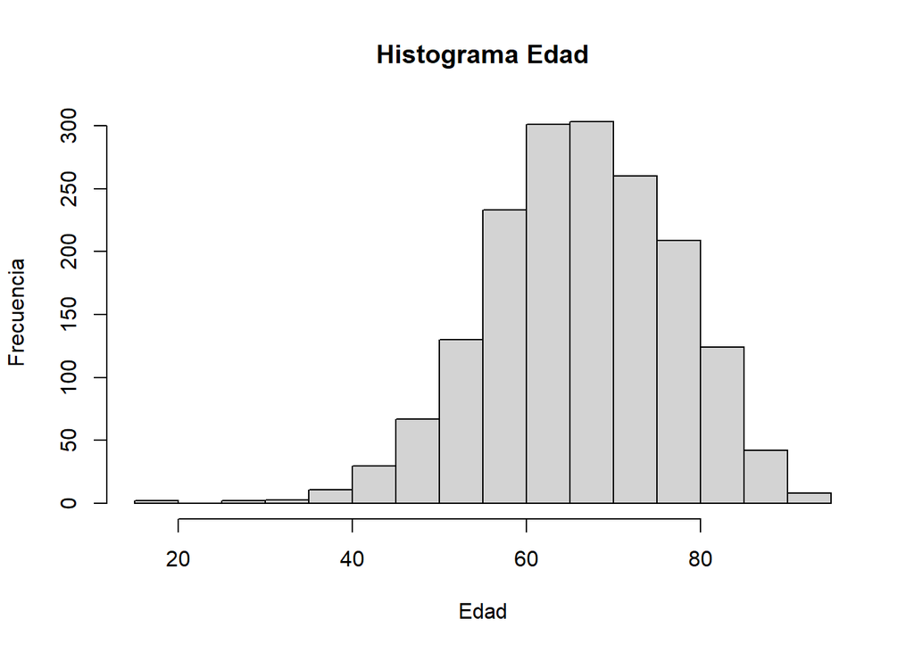

### Gráfico de densidad edad, Comuna de Antofagasta

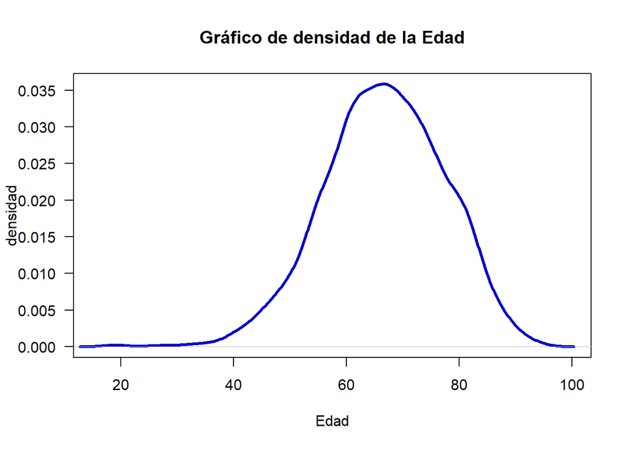

### Normal QQ, Comuna de Antofagasta

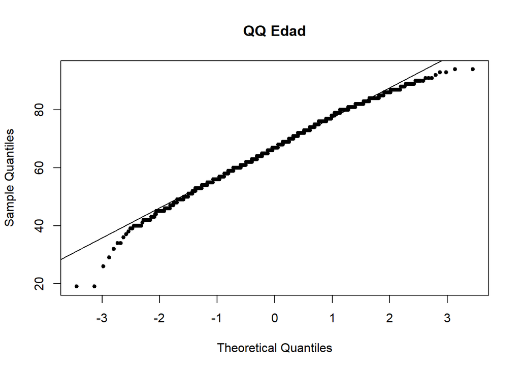

### Test de normalidad de Shapiro-Wilk, Comuna de Antofagasta

```
##
##  Shapiro-Wilk normality test
##
## data:  bd_pulmon_1$EDAD
## W = 0.9928, p-value = 1.847e-07
```

## Estadística descriptiva Bivariada, comuna de Antofagasta

### Número de casos por sexo y morfología, comuna de Antofagasta

```
##
##                                   Hombres Mujeres  Sum
##   Neoplasias, SAI                     529     269  798
##   Neoplasias Epiteliales, SAI         231     100  331
##   Neoplasias de células escamosas     319     109  428
##   Adenocarcinomas                      88      61  149
##   Otras morfologías                    11       7   18
##   Sum                                1178     546 1724
```

### Proporción de casos por sexo y morfología, comuna de Antofagasta

```
##
##                                   Hombres Mujeres    Sum
##   Neoplasias, SAI                   66.29   33.71 100.00
##   Neoplasias Epiteliales, SAI       69.79   30.21 100.00
##   Neoplasias de células escamosas   74.53   25.47 100.00
##   Adenocarcinomas                   59.06   40.94 100.00
##   Otras morfologías                 61.11   38.89 100.00
```

### Número de casos por sexo y extensión tumoral, comuna de Antofagasta

```
##
##               Hombres Mujeres  Sum
##   Localizado      484     223  707
##   Regional        143      70  213
##   Metástasis      317     149  466
##   Desconocido     235     104  339
##   Sum            1179     546 1725
```

### Proporción de casos por sexo y extensión tumoral, Comuna de Antofagasta

```
##
##               Hombres Mujeres    Sum
##   Localizado    68.46   31.54 100.00
##   Regional      67.14   32.86 100.00
##   Metástasis    68.03   31.97 100.00
##   Desconocido   69.32   30.68 100.00
```

### Número de casos por sexo y base diagnóstica, comuna de Antofagasta

```
##
##                                Hombres Mujeres  Sum
##   Solo DCO                         211      86  297
##   Clínico                           46      30   76
##   Investigación Clínica            260     141  401
##   Citología                          0       1    1
##   Histología de Metástasis          51      29   80
##   Histología de sitio primario     611     259  870
##   Sum                             1179     546 1725
```

### Proporción de casos por sexo y base diagnóstica, comuna de Antofagasta

```
##
##                                Hombres Mujeres    Sum
##   Solo DCO                       71.04   28.96 100.00
##   Clínico                        60.53   39.47 100.00
##   Investigación Clínica          64.84   35.16 100.00
##   Citología                       0.00  100.00 100.00
##   Histología de Metástasis       63.75   36.25 100.00
##   Histología de sitio primario   70.23   29.77 100.00
```

### Número de casos por Morfología y base diagnóstica, comuna de Antofagasta

```
##
##                                   Solo DCO Clínico Investigación Clínica
##   Neoplasias, SAI                      297      76                   401
##   Neoplasias Epiteliales, SAI            0       0                     0
##   Neoplasias de células escamosas        0       0                     0
##   Adenocarcinomas                        0       0                     0
##   Otras morfologías                      0       0                     0
##   Sum                                  297      76                   401
##
##                                   Citología Histología de Metástasis
##   Neoplasias, SAI                         1                        3
##   Neoplasias Epiteliales, SAI             0                       36
##   Neoplasias de células escamosas         0                       17
##   Adenocarcinomas                         0                       22
##   Otras morfologías                       0                        2
##   Sum                                     1                       80
##
##                                   Histología de sitio primario  Sum
##   Neoplasias, SAI                                           20  798
##   Neoplasias Epiteliales, SAI                              295  331
##   Neoplasias de células escamosas                          411  428
##   Adenocarcinomas                                          127  149
##   Otras morfologías                                         16   18
##   Sum                                                      869 1724
```

### Proporción de casos por Morfología y base diagnóstica, comuna de Antofagasta

```
##
##                                   Solo DCO Clínico Investigación Clínica
##   Neoplasias, SAI                    37.22    9.52                 50.25
##   Neoplasias Epiteliales, SAI         0.00    0.00                  0.00
##   Neoplasias de células escamosas     0.00    0.00                  0.00
##   Adenocarcinomas                     0.00    0.00                  0.00
##   Otras morfologías                   0.00    0.00                  0.00
##
##                                   Citología Histología de Metástasis
##   Neoplasias, SAI                      0.13                     0.38
##   Neoplasias Epiteliales, SAI          0.00                    10.88
##   Neoplasias de células escamosas      0.00                     3.97
##   Adenocarcinomas                      0.00                    14.77
##   Otras morfologías                    0.00                    11.11
##
##                                   Histología de sitio primario    Sum
##   Neoplasias, SAI                                         2.51 100.00
##   Neoplasias Epiteliales, SAI                            89.12 100.00
##   Neoplasias de células escamosas                        96.03 100.00
##   Adenocarcinomas                                        85.23 100.00
##   Otras morfologías                                      88.89 100.00
```

### Número de casos por Morfología y Extensión, comuna de Antofagasta

```
##
##                                   Localizado Regional Metástasis Desconocido
##   Neoplasias, SAI                        113       84        287         314
##   Neoplasias Epiteliales, SAI            205       46         71           9
##   Neoplasias de células escamosas        300       49         65          14
##   Adenocarcinomas                         82       29         36           2
##   Otras morfologías                        7        5          6           0
##   Sum                                    707      213        465         339
##
##                                    Sum
##   Neoplasias, SAI                  798
##   Neoplasias Epiteliales, SAI      331
##   Neoplasias de células escamosas  428
##   Adenocarcinomas                  149
##   Otras morfologías                 18
##   Sum                             1724
```

### Proporción de casos por Morfología y Extensión, comuna de Antofagasta

```
##
##                                   Localizado Regional Metástasis Desconocido
##   Neoplasias, SAI                      14.16    10.53      35.96       39.35
##   Neoplasias Epiteliales, SAI          61.93    13.90      21.45        2.72
##   Neoplasias de células escamosas      70.09    11.45      15.19        3.27
##   Adenocarcinomas                      55.03    19.46      24.16        1.34
##   Otras morfologías                    38.89    27.78      33.33        0.00
##
##                                      Sum
##   Neoplasias, SAI                 100.00
##   Neoplasias Epiteliales, SAI     100.00
##   Neoplasias de células escamosas 100.00
##   Adenocarcinomas                 100.00
##   Otras morfologías               100.00
```

### Número de casos por Extensión y Base diagnóstica, comuna de Antofagasta

```
##
##               Solo DCO Clínico Investigación Clínica Citología
##   Localizado         4      53                    48         0
##   Regional           3       1                    76         0
##   Metástasis        29      12                   237         1
##   Desconocido      261      10                    40         0
##   Sum              297      76                   401         1
##
##               Histología de Metástasis Histología de sitio primario  Sum
##   Localizado                        12                          590  707
##   Regional                           7                          126  213
##   Metástasis                        61                          126  466
##   Desconocido                        0                           28  339
##   Sum                               80                          870 1725
```

### Proporción de casos por Extensión y Base diagnóstica, filas, comuna de Antofagastas

```
##
##               Solo DCO Clínico Investigación Clínica Citología
##   Localizado      0.57    7.50                  6.79      0.00
##   Regional        1.41    0.47                 35.68      0.00
##   Metástasis      6.22    2.58                 50.86      0.21
##   Desconocido    76.99    2.95                 11.80      0.00
##
##               Histología de Metástasis Histología de sitio primario    Sum
##   Localizado                      1.70                        83.45 100.00
##   Regional                        3.29                        59.15 100.00
##   Metástasis                     13.09                        27.04 100.00
##   Desconocido                     0.00                         8.26 100.00
```

### Proporción de casos por Extensión y Base diagnóstica, columnas, Comuna de Antofagasta

```
##
##               Solo DCO Clínico Investigación Clínica Citología
##   Localizado      1.35   69.74                 11.97      0.00
##   Regional        1.01    1.32                 18.95      0.00
##   Metástasis      9.76   15.79                 59.10    100.00
##   Desconocido    87.88   13.16                  9.98      0.00
##   Sum           100.00  100.00                100.00    100.00
##
##               Histología de Metástasis Histología de sitio primario
##   Localizado                     15.00                        67.82
##   Regional                        8.75                        14.48
##   Metástasis                     76.25                        14.48
##   Desconocido                     0.00                         3.22
##   Sum                           100.00                       100.00
```

### Edad - Sexo

#### Boxplot edad vs sexo, Comuna de Antofagasta

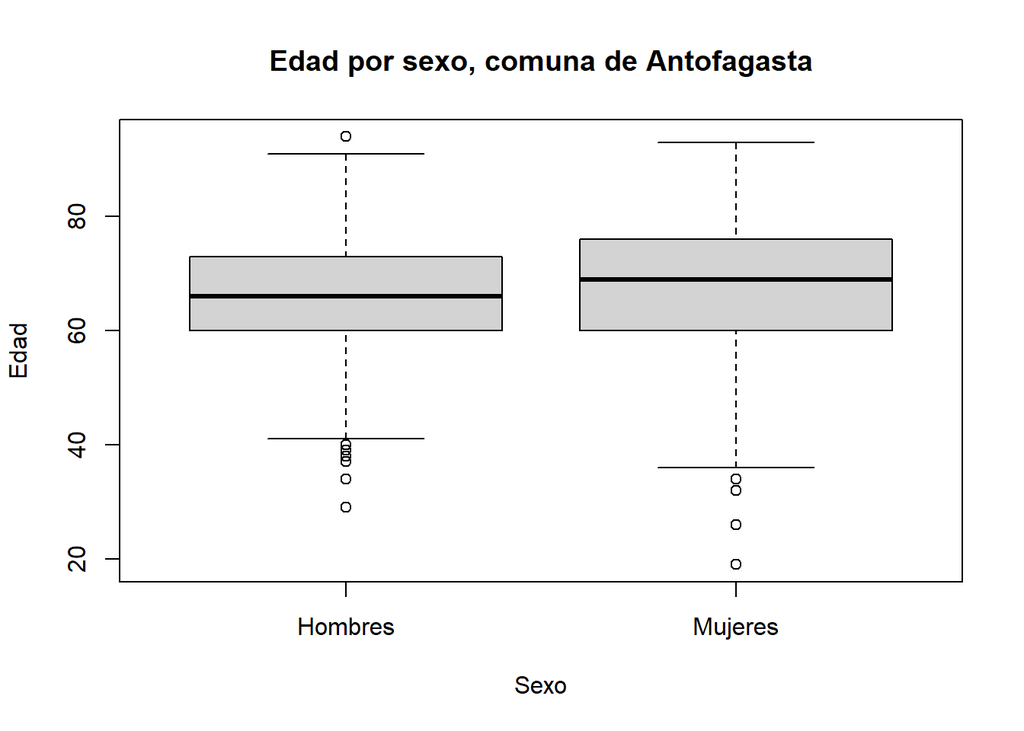

### Boxplot edad - morfologia, Comuna de Antofagasta

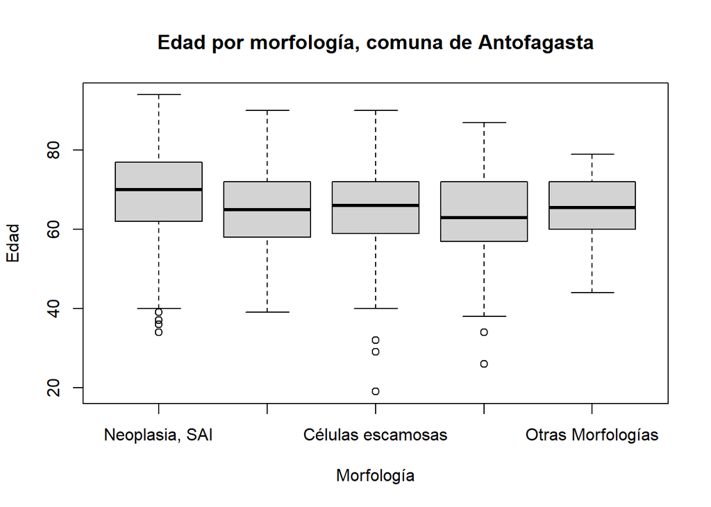

### Boxplot edad - extension, Comuna de Antofagasta

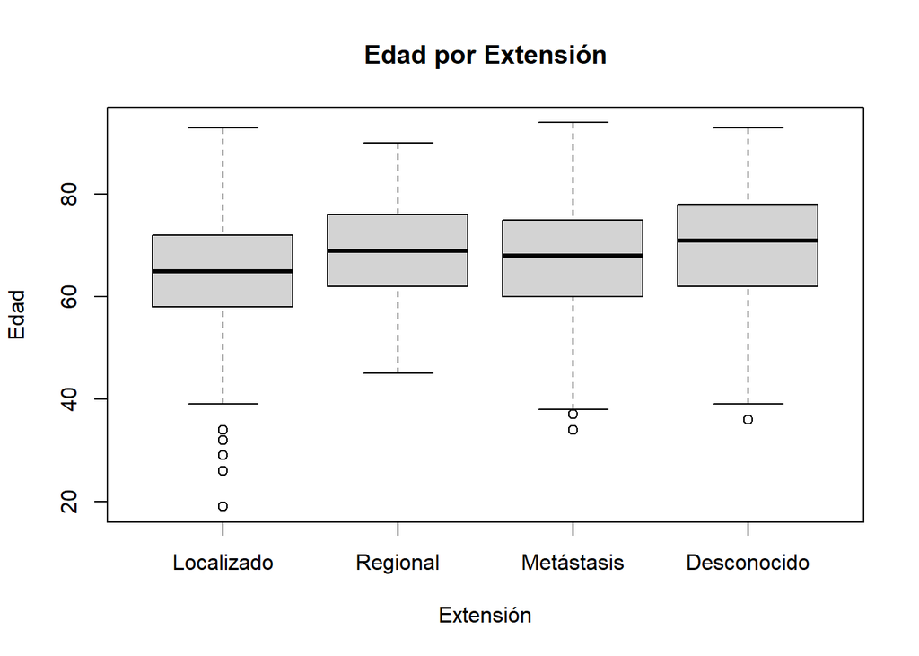

### Boxplot edad - base diagnóstica, Comuna de Antofagasta

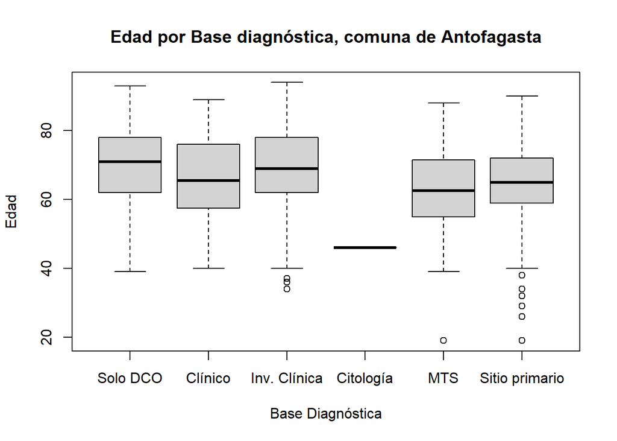

## Tasa de incidencia ajustada por año, Comuna de Antofagasta

| YEAR_DIAG | TASA_AJUSTADA |
| --- | --- |
| 2003 | 41.62921 |
| 2004 | 46.71891 |
| 2005 | 43.42588 |
| 2006 | 47.85793 |
| 2007 | 48.82915 |
| 2008 | 37.98148 |
| 2009 | 39.08880 |
| 2010 | 37.99934 |
| 2011 | 42.40896 |
| 2012 | 31.48038 |

[output cut: 3 more lines]

### Gráfico de la tasa de incidencia de cáncer de pulmón, ajustada por edad en Comuna de Antofagasta

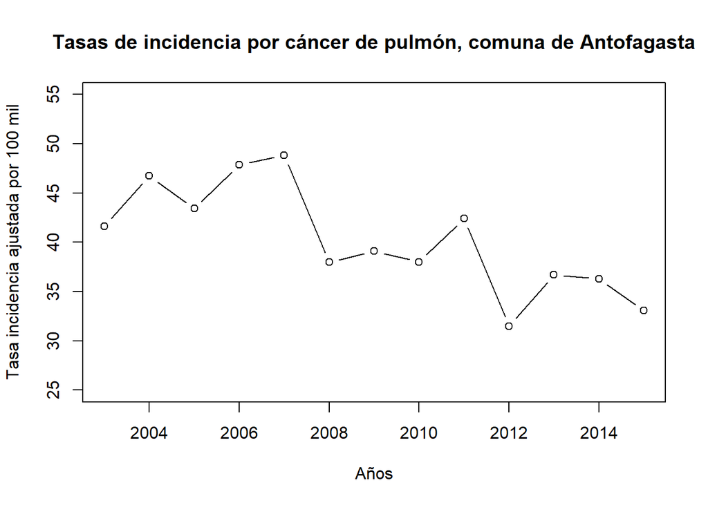

## Tasa de incidencia ajustada por edad y sexo, según año. Comuna de Antofagasta

| YEAR_DIAG | TASA_AJUSTADA | STD_ERROR |
| --- | --- | --- |
| 2003 | 29.79255 | 3.306368 |
| 2004 | 32.68930 | 3.544322 |
| 2005 | 31.78760 | 3.366883 |
| 2006 | 32.18637 | 3.350585 |
| 2007 | 36.50676 | 3.575206 |
| 2008 | 23.43858 | 2.740213 |
| 2009 | 26.26009 | 2.880649 |
| 2010 | 25.41093 | 2.855825 |
| 2011 | 29.80451 | 2.993367 |
| 2012 | 22.61775 | 2.587358 |

[output cut: 3 more lines]

| YEAR_DIAG | TASA_AJUSTADA | STD_ERROR |
| --- | --- | --- |
| 2003 | 11.836659 | 2.038360 |
| 2004 | 14.029607 | 2.285325 |
| 2005 | 11.638285 | 1.988180 |
| 2006 | 15.671557 | 2.350145 |
| 2007 | 12.322384 | 1.974012 |
| 2008 | 14.542902 | 2.110781 |
| 2009 | 12.828702 | 1.991794 |
| 2010 | 12.588404 | 1.968009 |
| 2011 | 12.604448 | 1.927982 |
| 2012 | 8.862621 | 1.546172 |

[output cut: 3 more lines]

### Gráfico de la tasa de incidencia de cáncer de pulmón, ajustada por edad y sexo en la comuna de Antofagasta.

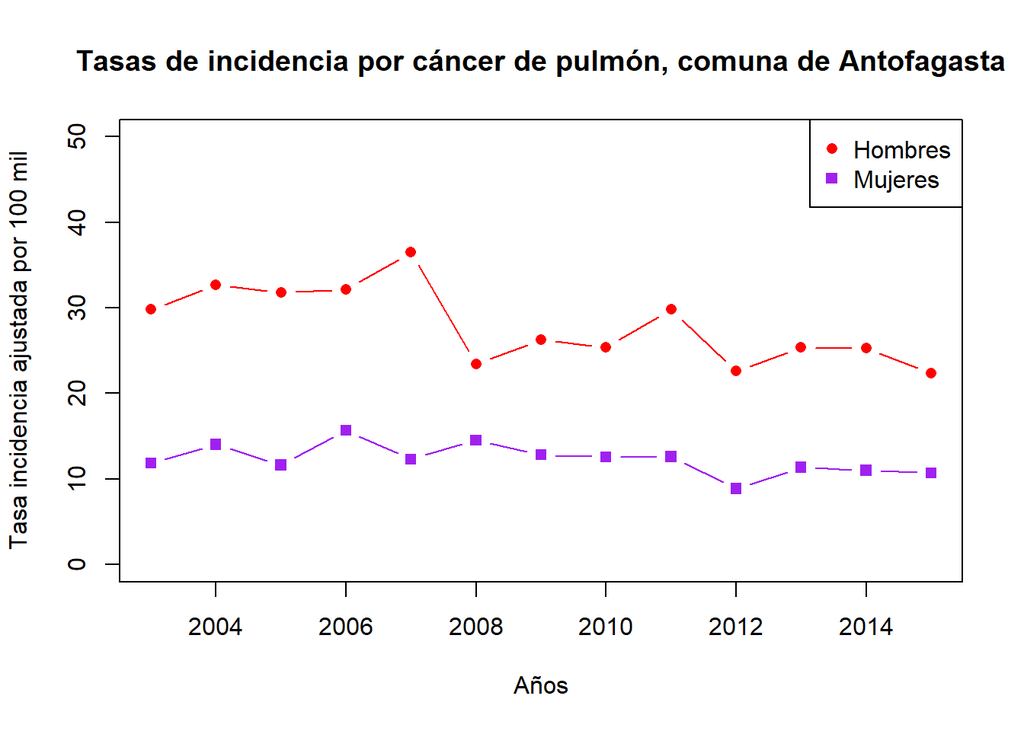

# Comuna de Calama

### Número de casos por sexo, Comuna de Calama

```
##
## Hombres Mujeres
##     157      56
```

### Proporción de casos por sexo, comuna de Calama

```
##
## Hombres Mujeres
##   73.71   26.29
```

### Casos según morfología, comuna de Calama

```
##
##                 Neoplasias, SAI     Neoplasias Epiteliales, SAI
##                             124                              32
## Neoplasias de células escamosas                 Adenocarcinomas
##                              30                              25
##               Otras morfologías
##                               2
```

### Proporción de casos según morfología, comuna de Calama

```
##
##                 Neoplasias, SAI     Neoplasias Epiteliales, SAI
##                            58.2                            15.0
## Neoplasias de células escamosas                 Adenocarcinomas
##                            14.1                            11.7
##               Otras morfologías
##                             0.9
```

### Casos según diferenciacion tumores, comuna de Calama

```
##
##           Bien Diferenciado Moderadamente Diferenciados
##                           2                          16
##           Poco Diferenciado                  Anaplásico
##                          29                           3
##                 Desconocido
##                         163
```

### Proporción de casos según diferenciación, Comuna de Calama

```
##
##           Bien Diferenciado Moderadamente Diferenciados
##                        0.94                        7.51
##           Poco Diferenciado                  Anaplásico
##                       13.62                        1.41
##                 Desconocido
##                       76.53
```

### Casos según extensión tumoral, Comuna de Calama

```
##
##  Localizado    Regional  Metástasis Desconocido
##          51          17          77          68
```

### Proporción de casos según extensión tumoral, Comuna de Calama

```
##
##  Localizado    Regional  Metástasis Desconocido
##       23.94        7.98       36.15       31.92
```

### Casos según base diagnóstico, Comuna de Calama

```
##
##                     Solo DCO                      Clínica
##                           53                            7
##        Investigación Clínica            Histología de MTS
##                           61                           14
## Histología de sitio primario
##                           78
```

### Proporción de casos según base diagnóstico, Comuna de Calama

```
##
##                     Solo DCO                      Clínica
##                        24.88                         3.29
##        Investigación Clínica            Histología de MTS
##                        28.64                         6.57
## Histología de sitio primario
##                        36.62
```

## Estadística descriptiva univariada cuantitativa, Pulmón. Comuna de Calama

### Edad, Comuna de Calama

| Mínimo | Máximo | Rango | Qu_25 | Qu_50 | Qu_75 | Media | Mediana | Varianza | Desv_Estándar | CV |
| --- | --- | --- | --- | --- | --- | --- | --- | --- | --- | --- |
| 26 | 90 | 64 | 61 | 68 | 76 | 68.1127 | 68 | 130.3457 | 11.4169 | 16.7618 |

### Histrograma edad, Comuna de Calama

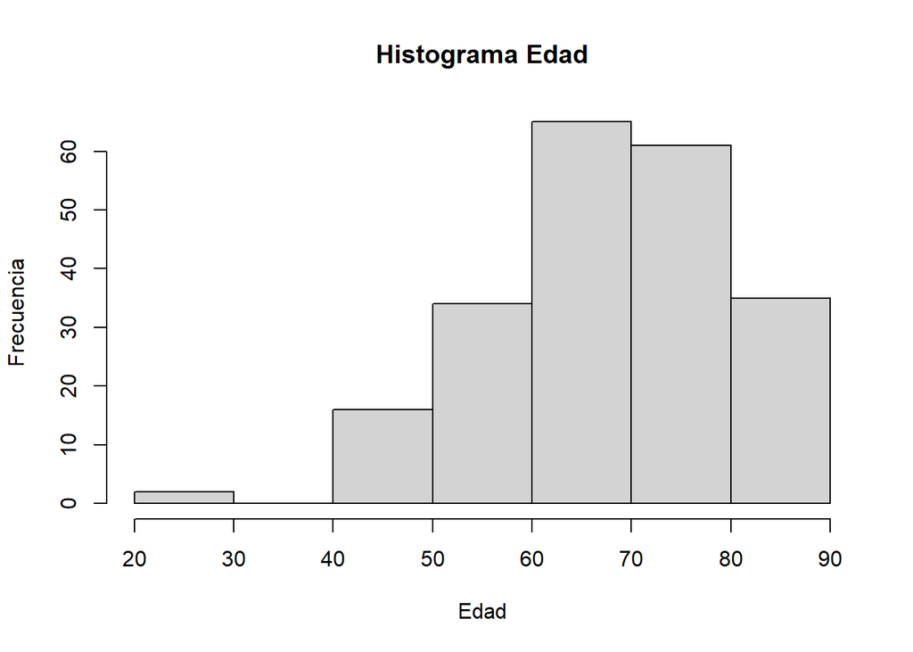

### Gráfico de densidad edad, Comuna de Calama

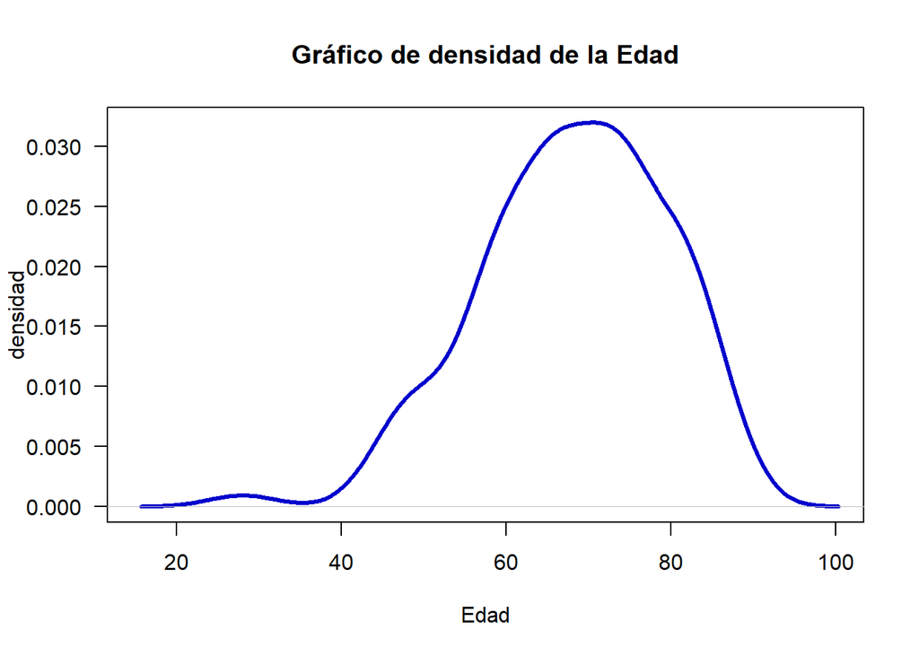

### Normal QQ, Comuna de Calama

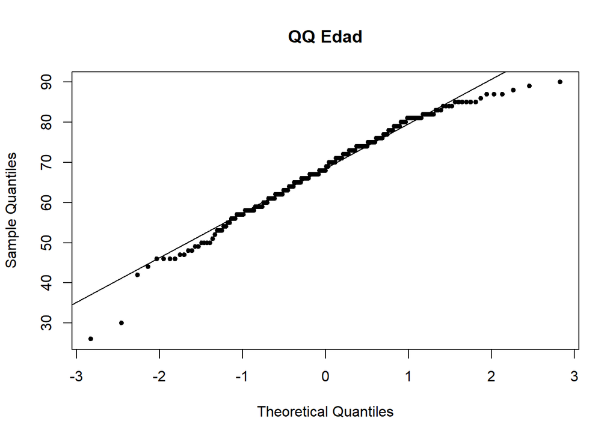

### Test de normalidad de Shapiro-Wilk, Comuna de Calama

```
##
##  Shapiro-Wilk normality test
##
## data:  bd_pulmon_2$EDAD
## W = 0.9769, p-value = 0.00143
```

## Estadística descriptiva Bivariada, comuna de Calama

### Número de casos por sexo y morfología, comuna de Calama

```
##
##                                   Hombres Mujeres Sum
##   Neoplasias, SAI                      92      32 124
##   Neoplasias Epiteliales, SAI          23       9  32
##   Neoplasias de células escamosas      22       8  30
##   Adenocarcinomas                      18       7  25
##   Otras morfologías                     2       0   2
##   Sum                                 157      56 213
```

### Proporción de casos por sexo y morfología, comuna de Calama

```
##
##                                   Hombres Mujeres    Sum
##   Neoplasias, SAI                   74.19   25.81 100.00
##   Neoplasias Epiteliales, SAI       71.88   28.12 100.00
##   Neoplasias de células escamosas   73.33   26.67 100.00
##   Adenocarcinomas                   72.00   28.00 100.00
##   Otras morfologías                100.00    0.00 100.00
```

### Número de casos por sexo y extensión tumoral, comuna de Calama

```
##
##               Hombres Mujeres Sum
##   Localizado       34      17  51
##   Regional         12       5  17
##   Metástasis       61      16  77
##   Desconocido      50      18  68
##   Sum             157      56 213
```

### Proporción de casos por sexo y extensión tumoral, Comuna de Calama

```
##
##               Hombres Mujeres    Sum
##   Localizado    66.67   33.33 100.00
##   Regional      70.59   29.41 100.00
##   Metástasis    79.22   20.78 100.00
##   Desconocido   73.53   26.47 100.00
```

### Número de casos por sexo y base diagnóstica, comuna de Calama

```
##
##                                Hombres Mujeres Sum
##   Solo DCO                          41      12  53
##   Clínico                            5       2   7
##   Investigación Clínica             44      17  61
##   Histología de Metástasis           9       5  14
##   Histología de sitio primario      58      20  78
##   Sum                              157      56 213
```

### Proporción de casos por sexo y base diagnóstica, comuna de Calama

```
##
##                                Hombres Mujeres    Sum
##   Solo DCO                       77.36   22.64 100.00
##   Clínico                        71.43   28.57 100.00
##   Investigación Clínica          72.13   27.87 100.00
##   Histología de Metástasis       64.29   35.71 100.00
##   Histología de sitio primario   74.36   25.64 100.00
```

### Número de casos por Morfología y base diagnóstica, comuna de Calama

```
##
##                                   Solo DCO Clínico Investigación Clínica
##   Neoplasias, SAI                       53       7                    61
##   Neoplasias Epiteliales, SAI            0       0                     0
##   Neoplasias de células escamosas        0       0                     0
##   Adenocarcinomas                        0       0                     0
##   Otras morfologías                      0       0                     0
##   Sum                                   53       7                    61
##
##                                   Citología Histología de Metástasis
##   Neoplasias, SAI                         0                        0
##   Neoplasias Epiteliales, SAI             0                        6
##   Neoplasias de células escamosas         0                        2
##   Adenocarcinomas                         0                        6
##   Otras morfologías                       0                        0
##   Sum                                     0                       14
##
##                                   Histología de sitio primario Sum
##   Neoplasias, SAI                                            3 124
##   Neoplasias Epiteliales, SAI                               26  32
##   Neoplasias de células escamosas                           28  30
##   Adenocarcinomas                                           19  25
##   Otras morfologías                                          2   2
##   Sum                                                       78 213
```

### Proporción de casos por Morfología y base diagnóstica, comuna de Calama

```
##
##                                   Solo DCO Clínico Investigación Clínica
##   Neoplasias, SAI                    42.74    5.65                 49.19
##   Neoplasias Epiteliales, SAI         0.00    0.00                  0.00
##   Neoplasias de células escamosas     0.00    0.00                  0.00
##   Adenocarcinomas                     0.00    0.00                  0.00
##   Otras morfologías                   0.00    0.00                  0.00
##
##                                   Citología Histología de Metástasis
##   Neoplasias, SAI                      0.00                     0.00
##   Neoplasias Epiteliales, SAI          0.00                    18.75
##   Neoplasias de células escamosas      0.00                     6.67
##   Adenocarcinomas                      0.00                    24.00
##   Otras morfologías                    0.00                     0.00
##
##                                   Histología de sitio primario    Sum
##   Neoplasias, SAI                                         2.42 100.00
##   Neoplasias Epiteliales, SAI                            81.25 100.00
##   Neoplasias de células escamosas                        93.33 100.00
##   Adenocarcinomas                                        76.00 100.00
##   Otras morfologías                                     100.00 100.00
```

### Número de casos por Morfología y Extensión, comuna de Calama

```
##
##                                   Localizado Regional Metástasis Desconocido
##   Neoplasias, SAI                          6        7         46          65
##   Neoplasias Epiteliales, SAI             17        3         11           1
##   Neoplasias de células escamosas         18        3          9           0
##   Adenocarcinomas                          9        3         11           2
##   Otras morfologías                        1        1          0           0
##   Sum                                     51       17         77          68
##
##                                   Sum
##   Neoplasias, SAI                 124
##   Neoplasias Epiteliales, SAI      32
##   Neoplasias de células escamosas  30
##   Adenocarcinomas                  25
##   Otras morfologías                 2
##   Sum                             213
```

### Proporción de casos por Morfología y Extensión, comuna de Calama

```
##
##                                   Localizado Regional Metástasis Desconocido
##   Neoplasias, SAI                       4.84     5.65      37.10       52.42
##   Neoplasias Epiteliales, SAI          53.12     9.38      34.38        3.12
##   Neoplasias de células escamosas      60.00    10.00      30.00        0.00
##   Adenocarcinomas                      36.00    12.00      44.00        8.00
##   Otras morfologías                    50.00    50.00       0.00        0.00
##
##                                      Sum
##   Neoplasias, SAI                 100.00
##   Neoplasias Epiteliales, SAI     100.00
##   Neoplasias de células escamosas 100.00
##   Adenocarcinomas                 100.00
##   Otras morfologías               100.00
```

### Número de casos por Extensión y Base diagnóstica, comuna de Calama

```
##
##               Solo DCO Clínico Investigación Clínica Citología
##   Localizado         0       3                     2         0
##   Regional           0       0                     6         0
##   Metástasis         4       1                    41         0
##   Desconocido       49       3                    12         0
##   Sum               53       7                    61         0
##
##               Histología de Metástasis Histología de sitio primario Sum
##   Localizado                         3                           43  51
##   Regional                           0                           11  17
##   Metástasis                        11                           20  77
##   Desconocido                        0                            4  68
##   Sum                               14                           78 213
```

### Proporción de casos por Extensión y Base diagnóstica, filas, comuna de Calama

```
##
##               Solo DCO Clínico Investigación Clínica Citología
##   Localizado      0.00    5.88                  3.92      0.00
##   Regional        0.00    0.00                 35.29      0.00
##   Metástasis      5.19    1.30                 53.25      0.00
##   Desconocido    72.06    4.41                 17.65      0.00
##
##               Histología de Metástasis Histología de sitio primario    Sum
##   Localizado                      5.88                        84.31 100.00
##   Regional                        0.00                        64.71 100.00
##   Metástasis                     14.29                        25.97 100.00
##   Desconocido                     0.00                         5.88 100.00
```

### Proporción de casos por Extensión y Base diagnóstica, columnas, Comuna de Calama

```
##
##               Solo DCO Clínico Investigación Clínica Citología
##   Localizado      0.00   42.86                  3.28
##   Regional        0.00    0.00                  9.84
##   Metástasis      7.55   14.29                 67.21
##   Desconocido    92.45   42.86                 19.67
##   Sum           100.00  100.00                100.00
##
##               Histología de Metástasis Histología de sitio primario
##   Localizado                     21.43                        55.13
##   Regional                        0.00                        14.10
##   Metástasis                     78.57                        25.64
##   Desconocido                     0.00                         5.13
##   Sum                           100.00                       100.00
```

### Edad - Sexo

#### Boxplot edad vs sexo, Comuna de Calama

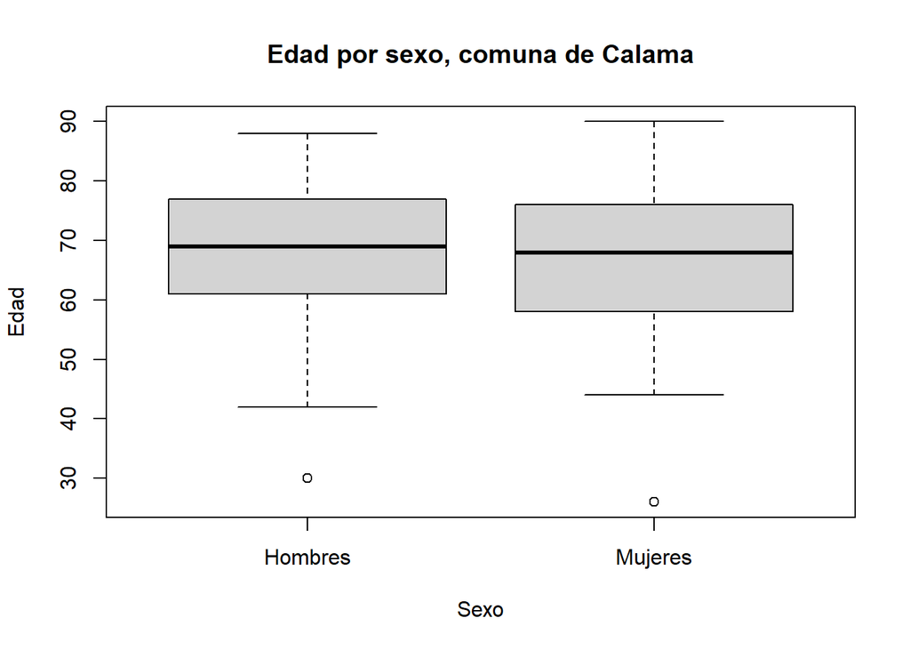

### Boxplot edad - morfologia, Comuna de Calama

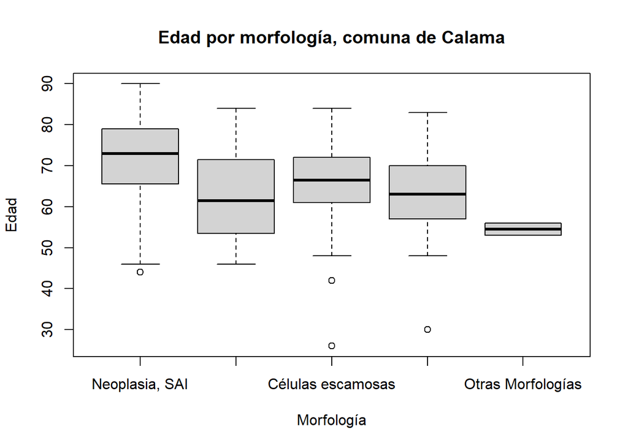

### Boxplot edad - extension, Comuna de Calama

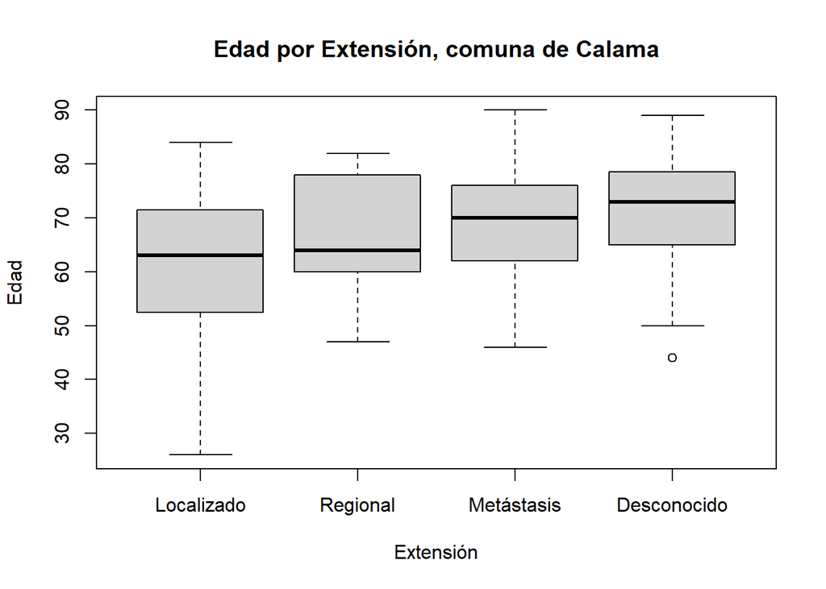

### Boxplot edad - base diagnóstica, Comuna de Calama

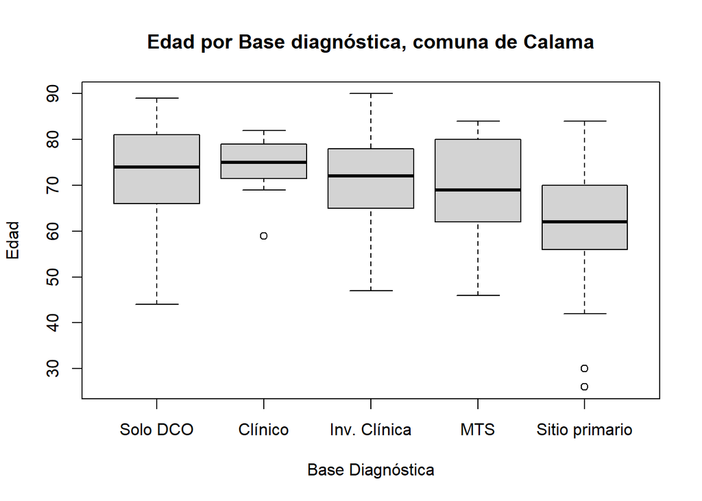

## Tasa de incidencia ajustada por año, Comuna de Calama

| YEAR_DIAG | TASA_AJUSTADA |
| --- | --- |
| 2003 | 10.941394 |
| 2004 | 12.402587 |
| 2005 | 15.432497 |
| 2006 | 16.604538 |
| 2007 | 15.009115 |
| 2008 | 9.678686 |
| 2009 | 8.901761 |
| 2010 | 19.350266 |
| 2011 | 14.272110 |
| 2012 | 8.202522 |

[output cut: 3 more lines]

### Gráfico de la tasa de incidencia de cáncer de pulmón, ajustada por edad en Comuna de Calama

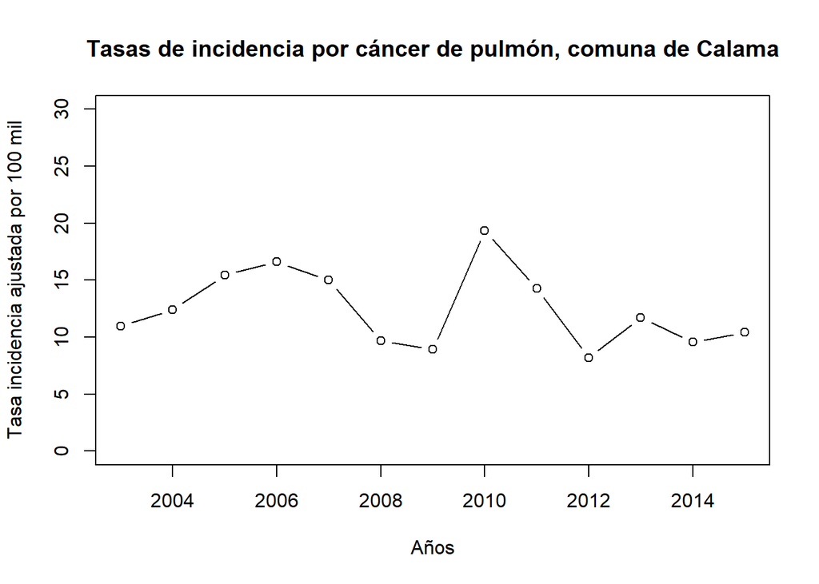

## Tasa de incidencia ajustada por edad y sexo, según año. Comuna de Calama

| YEAR_DIAG | TASA_AJUSTADA | STD_ERROR |
| --- | --- | --- |
| 2003 | 9.031481 | 3.047323 |
| 2004 | 7.403443 | 2.521567 |
| 2005 | 10.992111 | 3.277163 |
| 2006 | 13.347176 | 3.491385 |
| 2007 | 10.036819 | 2.856255 |
| 2008 | 7.616830 | 2.606508 |
| 2009 | 8.353440 | 2.465436 |
| 2010 | 13.780940 | 3.319866 |
| 2011 | 8.835837 | 2.694463 |
| 2012 | 6.425323 | 2.059904 |

[output cut: 3 more lines]

| YEAR_DIAG | TASA_AJUSTADA | STD_ERROR |
| --- | --- | --- |
| 2003 | 1.9099134 | 1.1026932 |
| 2004 | 4.9991438 | 2.2555585 |
| 2005 | 4.4403858 | 2.0437162 |
| 2006 | 3.2573613 | 1.6800168 |
| 2007 | 4.9722956 | 2.1013448 |
| 2008 | 2.0618557 | 1.4579521 |
| 2009 | 0.5483208 | 0.5483208 |
| 2010 | 5.5693265 | 2.0222927 |
| 2011 | 5.4362735 | 2.0964095 |
| 2012 | 1.7771989 | 1.0385454 |

[output cut: 3 more lines]

### Gráfico de la tasa de incidencia de cáncer de pulmón, ajustada por edad y sexo en la comuna de Calama

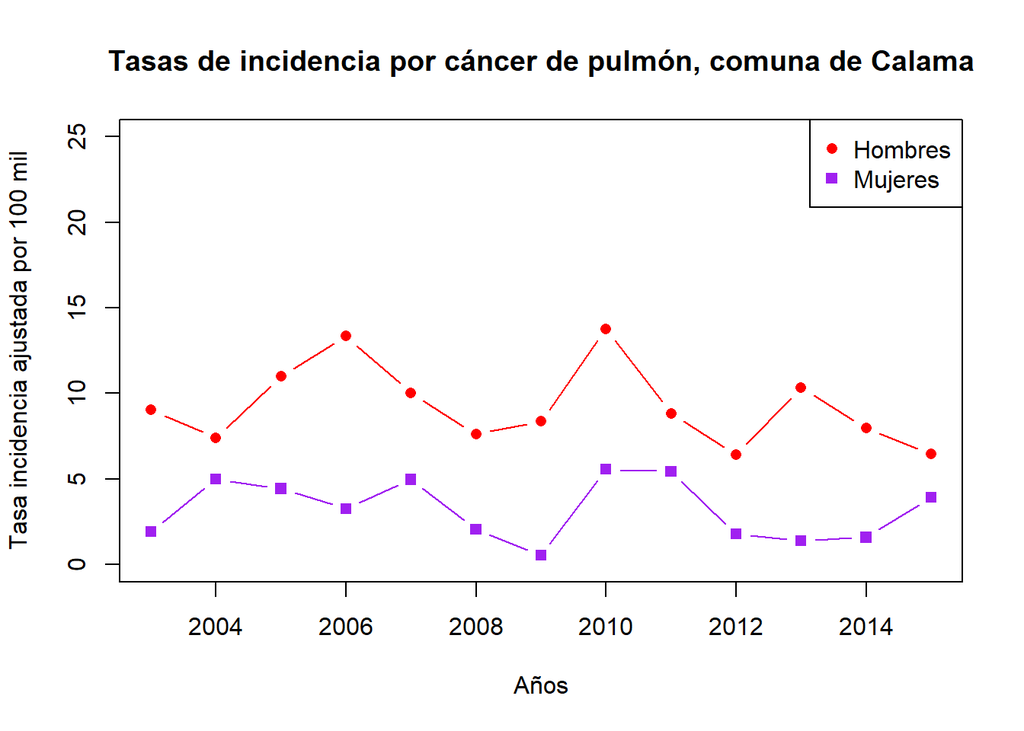

# Comuna de Tocopilla

### Número de casos por sexo, Comuna de Tocopilla

```
##
## Hombres Mujeres
##     119      37
```

### Proporción de casos por sexo, comuna de Tocopilla

```
##
## Hombres Mujeres
##   76.28   23.72
```

### Casos según morfología, comuna de Tocopilla

```
##
##                 Neoplasias, SAI     Neoplasias Epiteliales, SAI
##                              87                              30
## Neoplasias de células escamosas                 Adenocarcinomas
##                              26                              13
```

### Proporción de casos según morfología, comuna de Tocopilla

```
##
##                 Neoplasias, SAI     Neoplasias Epiteliales, SAI
##                            55.8                            19.2
## Neoplasias de células escamosas                 Adenocarcinomas
##                            16.7                             8.3
```

### Casos según diferenciacion tumores, comuna de Tocopilla

```
##
##           Bien Diferenciado Moderadamente Diferenciados
##                           2                          20
##           Poco Diferenciado                  Anaplásico
##                          17                           6
##                 Desconocido
##                         111
```

### Proporción de casos según diferenciación, Comuna de Tocopilla

```
##
##           Bien Diferenciado Moderadamente Diferenciados
##                        1.28                       12.82
##           Poco Diferenciado                  Anaplásico
##                       10.90                        3.85
##                 Desconocido
##                       71.15
```

### Casos según extensión tumoral, Comuna de Tocopilla

```
##
##  Localizado    Regional  Metástasis Desconocido
##          61          14          33          48
```

### Proporción de casos según extensión tumoral, Comuna de Tocopilla

```
##
##  Localizado    Regional  Metástasis Desconocido
##       39.10        8.97       21.15       30.77
```

### Casos según base diagnóstico, Comuna de Tocopilla

```
##
##                     Solo DCO                      Clínica
##                           30                           14
##        Investigación Clínica            Histología de MTS
##                           43                            4
## Histología de sitio primario
##                           65
```

### Proporción de casos según base diagnóstico, Comuna de Tocopilla

```
##
##                     Solo DCO                      Clínica
##                        19.23                         8.97
##        Investigación Clínica            Histología de MTS
##                        27.56                         2.56
## Histología de sitio primario
##                        41.67
```

## Estadística descriptiva univariada cuantitativa, Pulmón. Comuna de Tocopilla

### Edad, Comuna de Tocopilla

| Mínimo | Máximo | Rango | Qu_25 | Qu_50 | Qu_75 | Media | Mediana | Varianza | Desv_Estándar | CV |
| --- | --- | --- | --- | --- | --- | --- | --- | --- | --- | --- |
| 41 | 88 | 47 | 60 | 68 | 74.25 | 67.1987 | 68 | 96.8828 | 9.8429 | 14.6475 |

### Histrograma edad, Comuna de Tocopilla

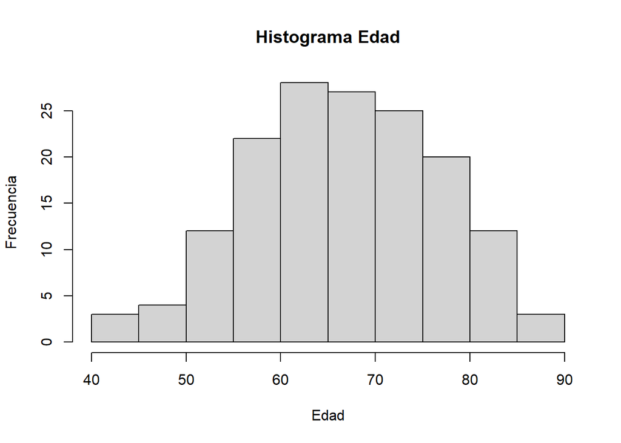

### Gráfico de densidad edad, Comuna de Tocopilla

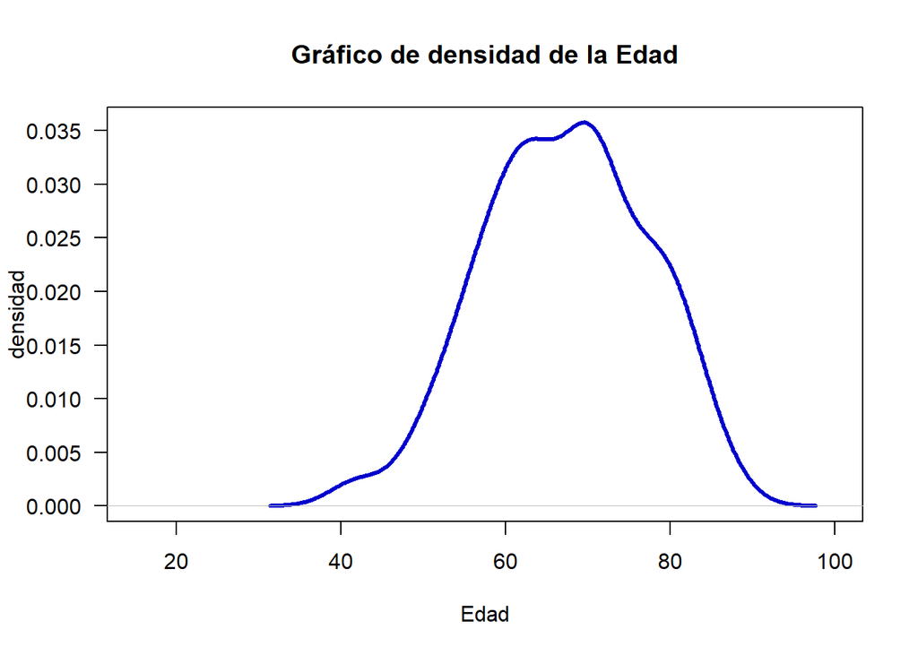

### Normal QQ, Comuna de Tocopilla

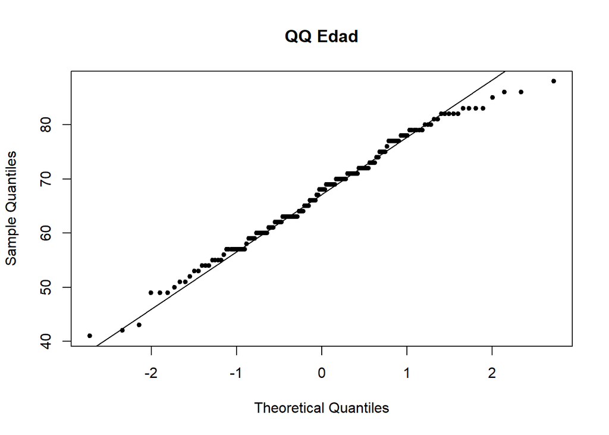

### Test de normalidad de Shapiro-Wilk, Comuna de Tocopilla

```
##
##  Shapiro-Wilk normality test
##
## data:  bd_pulmon_3$EDAD
## W = 0.98751, p-value = 0.1774
```

## Estadística descriptiva Bivariada, comuna de Tocopilla

### Número de casos por sexo y morfología, comuna de Tocopilla

```
##
##                                   Hombres Mujeres Sum
##   Neoplasias, SAI                      63      24  87
##   Neoplasias Epiteliales, SAI          25       5  30
##   Neoplasias de células escamosas      20       6  26
##   Adenocarcinomas                      11       2  13
##   Sum                                 119      37 156
```

### Proporción de casos por sexo y morfología, comuna de Tocopilla

```
##
##                                   Hombres Mujeres    Sum
##   Neoplasias, SAI                   72.41   27.59 100.00
##   Neoplasias Epiteliales, SAI       83.33   16.67 100.00
##   Neoplasias de células escamosas   76.92   23.08 100.00
##   Adenocarcinomas                   84.62   15.38 100.00
```

### Número de casos por sexo y extensión tumoral, comuna de Tocopilla

```
##
##               Hombres Mujeres Sum
##   Localizado       49      12  61
##   Regional          7       7  14
##   Metástasis       26       7  33
##   Desconocido      37      11  48
##   Sum             119      37 156
```

### Proporción de casos por sexo y extensión tumoral, Comuna de Tocopilla

```
##
##               Hombres Mujeres    Sum
##   Localizado    80.33   19.67 100.00
##   Regional      50.00   50.00 100.00
##   Metástasis    78.79   21.21 100.00
##   Desconocido   77.08   22.92 100.00
```

### Número de casos por sexo y base diagnóstica, comuna de Tocopilla

```
##
##                                Hombres Mujeres Sum
##   Solo DCO                          23       7  30
##   Clínico                           11       3  14
##   Investigación Clínica             29      14  43
##   Histología de Metástasis           4       0   4
##   Histología de sitio primario      52      13  65
##   Sum                              119      37 156
```

### Proporción de casos por sexo y base diagnóstica, comuna de Tocopilla

```
##
##                                Hombres Mujeres    Sum
##   Solo DCO                       76.67   23.33 100.00
##   Clínico                        78.57   21.43 100.00
##   Investigación Clínica          67.44   32.56 100.00
##   Histología de Metástasis      100.00    0.00 100.00
##   Histología de sitio primario   80.00   20.00 100.00
```

### Número de casos por Morfología y base diagnóstica, comuna de Tocopilla

```
##
##                                   Solo DCO Clínico Investigación Clínica
##   Neoplasias, SAI                       30      14                    43
##   Neoplasias Epiteliales, SAI            0       0                     0
##   Neoplasias de células escamosas        0       0                     0
##   Adenocarcinomas                        0       0                     0
##   Otras morfologías                      0       0                     0
##   Sum                                   30      14                    43
##
##                                   Citología Histología de Metástasis
##   Neoplasias, SAI                         0                        0
##   Neoplasias Epiteliales, SAI             0                        0
##   Neoplasias de células escamosas         0                        1
##   Adenocarcinomas                         0                        3
##   Otras morfologías                       0                        0
##   Sum                                     0                        4
##
##                                   Histología de sitio primario Sum
##   Neoplasias, SAI                                            0  87
##   Neoplasias Epiteliales, SAI                               30  30
##   Neoplasias de células escamosas                           25  26
##   Adenocarcinomas                                           10  13
##   Otras morfologías                                          0   0
##   Sum                                                       65 156
```

### Proporción de casos por Morfología y base diagnóstica, comuna de Tocopilla

```
##
##                                   Solo DCO Clínico Investigación Clínica
##   Neoplasias, SAI                    34.48   16.09                 49.43
##   Neoplasias Epiteliales, SAI         0.00    0.00                  0.00
##   Neoplasias de células escamosas     0.00    0.00                  0.00
##   Adenocarcinomas                     0.00    0.00                  0.00
##   Otras morfologías
##
##                                   Citología Histología de Metástasis
##   Neoplasias, SAI                      0.00                     0.00
##   Neoplasias Epiteliales, SAI          0.00                     0.00
##   Neoplasias de células escamosas      0.00                     3.85
##   Adenocarcinomas                      0.00                    23.08
##   Otras morfologías
##
##                                   Histología de sitio primario    Sum
##   Neoplasias, SAI                                         0.00 100.00
##   Neoplasias Epiteliales, SAI                           100.00 100.00
##   Neoplasias de células escamosas                        96.15 100.00
##   Adenocarcinomas                                        76.92 100.00
##   Otras morfologías
```

### Número de casos por Morfología y Extensión, comuna de Tocopilla

```
##
##                                   Localizado Regional Metástasis Desconocido
##   Neoplasias, SAI                         12        7         23          45
##   Neoplasias Epiteliales, SAI             22        3          4           1
##   Neoplasias de células escamosas         20        3          2           1
##   Adenocarcinomas                          7        1          4           1
##   Otras morfologías                        0        0          0           0
##   Sum                                     61       14         33          48
##
##                                   Sum
##   Neoplasias, SAI                  87
##   Neoplasias Epiteliales, SAI      30
##   Neoplasias de células escamosas  26
##   Adenocarcinomas                  13
##   Otras morfologías                 0
##   Sum                             156
```

### Proporción de casos por Morfología y Extensión, comuna de Tocopilla

```
##
##                                   Localizado Regional Metástasis Desconocido
##   Neoplasias, SAI                      13.79     8.05      26.44       51.72
##   Neoplasias Epiteliales, SAI          73.33    10.00      13.33        3.33
##   Neoplasias de células escamosas      76.92    11.54       7.69        3.85
##   Adenocarcinomas                      53.85     7.69      30.77        7.69
##   Otras morfologías
##
##                                      Sum
##   Neoplasias, SAI                 100.00
##   Neoplasias Epiteliales, SAI     100.00
##   Neoplasias de células escamosas 100.00
##   Adenocarcinomas                 100.00
##   Otras morfologías
```

### Número de casos por Extensión y Base diagnóstica, comuna de Tocopilla

```
##
##               Solo DCO Clínico Investigación Clínica Citología
##   Localizado         0       4                     8         0
##   Regional           0       0                     7         0
##   Metástasis         1       1                    21         0
##   Desconocido       29       9                     7         0
##   Sum               30      14                    43         0
##
##               Histología de Metástasis Histología de sitio primario Sum
##   Localizado                         0                           49  61
##   Regional                           0                            7  14
##   Metástasis                         4                            6  33
##   Desconocido                        0                            3  48
##   Sum                                4                           65 156
```

### Proporción de casos por Extensión y Base diagnóstica, filas, comuna de Tocopilla

```
##
##               Solo DCO Clínico Investigación Clínica Citología
##   Localizado      0.00    6.56                 13.11      0.00
##   Regional        0.00    0.00                 50.00      0.00
##   Metástasis      3.03    3.03                 63.64      0.00
##   Desconocido    60.42   18.75                 14.58      0.00
##
##               Histología de Metástasis Histología de sitio primario    Sum
##   Localizado                      0.00                        80.33 100.00
##   Regional                        0.00                        50.00 100.00
##   Metástasis                     12.12                        18.18 100.00
##   Desconocido                     0.00                         6.25 100.00
```

### Proporción de casos por Extensión y Base diagnóstica, columnas, Comuna de Tocopilla

```
##
##               Solo DCO Clínico Investigación Clínica Citología
##   Localizado      0.00   28.57                 18.60
##   Regional        0.00    0.00                 16.28
##   Metástasis      3.33    7.14                 48.84
##   Desconocido    96.67   64.29                 16.28
##   Sum           100.00  100.00                100.00
##
##               Histología de Metástasis Histología de sitio primario
##   Localizado                      0.00                        75.38
##   Regional                        0.00                        10.77
##   Metástasis                    100.00                         9.23
##   Desconocido                     0.00                         4.62
##   Sum                           100.00                       100.00
```

### Edad - Sexo

#### Boxplot edad vs sexo, Comuna de Tocopilla

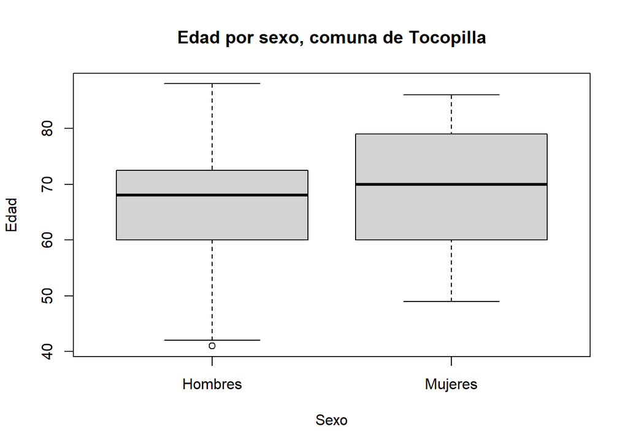

### Boxplot edad - morfologia, Comuna de Tocopilla

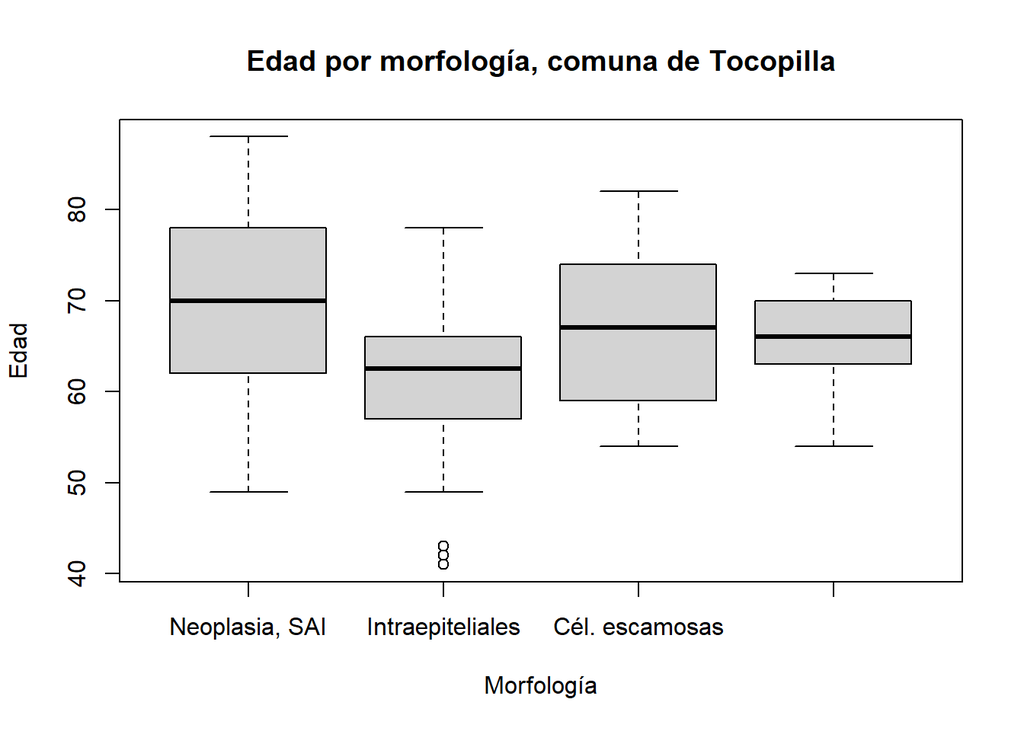

### Boxplot edad - extension, Comuna de Tocopilla

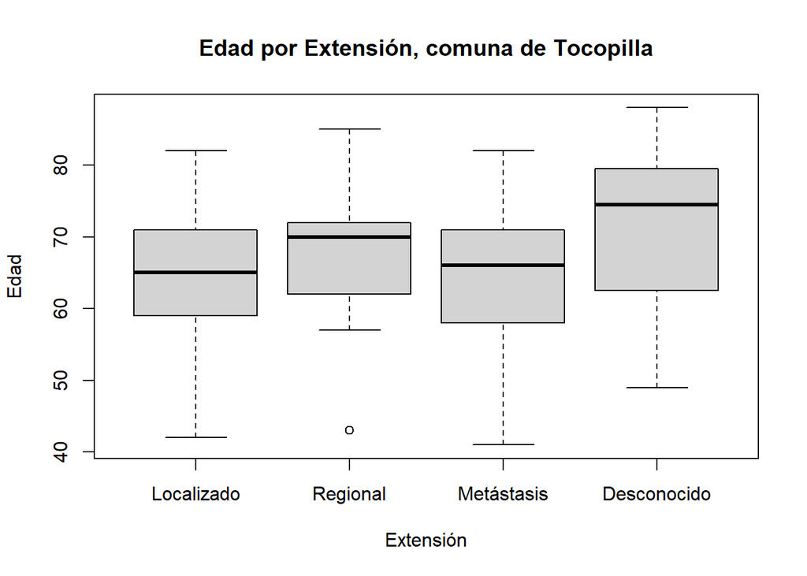

### Boxplot edad - base diagnóstica, Comuna de Tocopilla

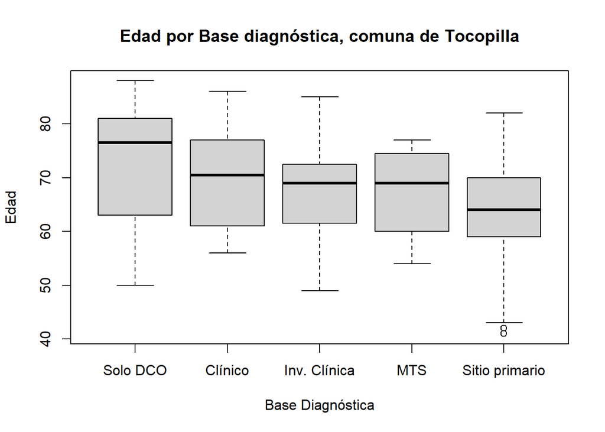

## Tasa de incidencia ajustada por año, Comuna de Tocopilla

| YEAR_DIAG | TASA_AJUSTADA |
| --- | --- |
| 2003 | 35.32679 |
| 2004 | 33.80850 |
| 2005 | 32.77017 |
| 2006 | 52.36557 |
| 2007 | 33.27436 |
| 2008 | 37.07147 |
| 2009 | 58.61083 |
| 2010 | 35.93480 |
| 2011 | 18.64564 |
| 2012 | 53.66932 |

[output cut: 3 more lines]

### Gráfico de la tasa de incidencia de cáncer de pulmón, ajustada por edad en Comuna de Tocopilla

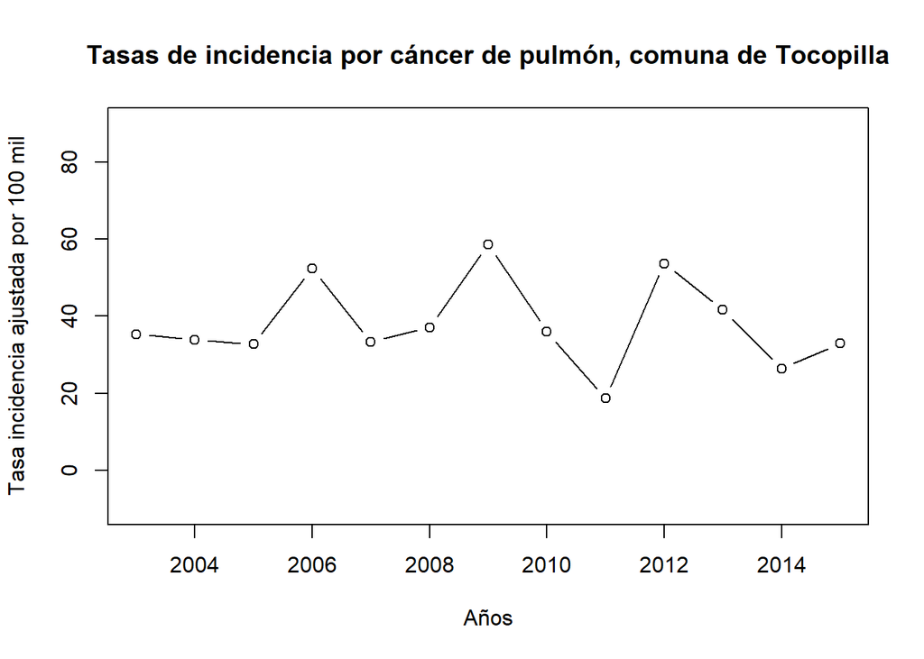

| YEAR_DIAG | TASA_AJUSTADA | STD_ERROR |
| --- | --- | --- |
| 2003 | 32.273351 | 10.873152 |
| 2004 | 27.061556 | 9.888515 |
| 2005 | 26.416672 | 10.055294 |
| 2006 | 43.815757 | 12.496775 |
| 2007 | 30.811302 | 10.404881 |
| 2008 | 29.473243 | 10.122031 |
| 2009 | 48.303535 | 12.422312 |
| 2010 | 23.250019 | 8.472314 |
| 2011 | 8.184538 | 4.778893 |
| 2012 | 47.217709 | 12.691537 |

[output cut: 3 more lines]

| YEAR_DIAG | TASA_AJUSTADA | STD_ERROR |
| --- | --- | --- |
| 2003 | 3.053435 | 3.053435 |
| 2004 | 6.746946 | 5.038715 |
| 2005 | 6.353496 | 4.723204 |
| 2006 | 8.549818 | 6.048240 |
| 2007 | 2.463054 | 2.463054 |
| 2008 | 7.598225 | 4.456631 |
| 2009 | 10.307295 | 5.227330 |
| 2010 | 12.684776 | 6.496512 |
| 2011 | 10.461103 | 6.045390 |
| 2012 | 6.451613 | 4.561979 |

[output cut: 3 more lines]

### Gráfico de la tasa de incidencia de cáncer de pulmón, ajustada por edad y sexo en la comuna de Tocopilla

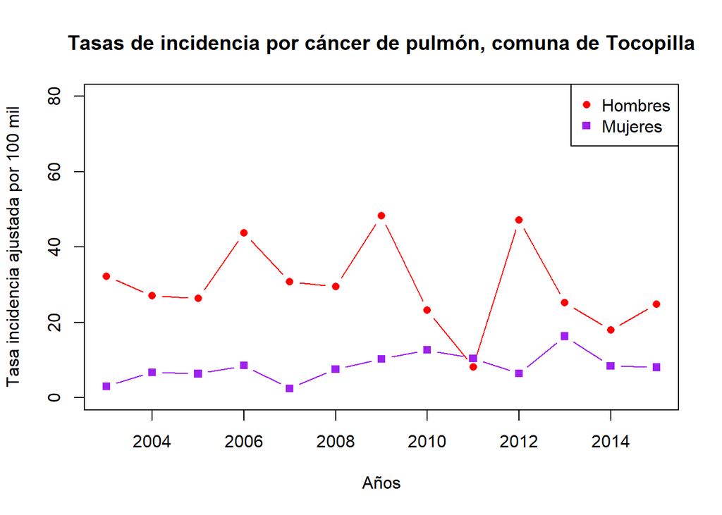

# Plot tasas de incidencia por cáncer de pulmón

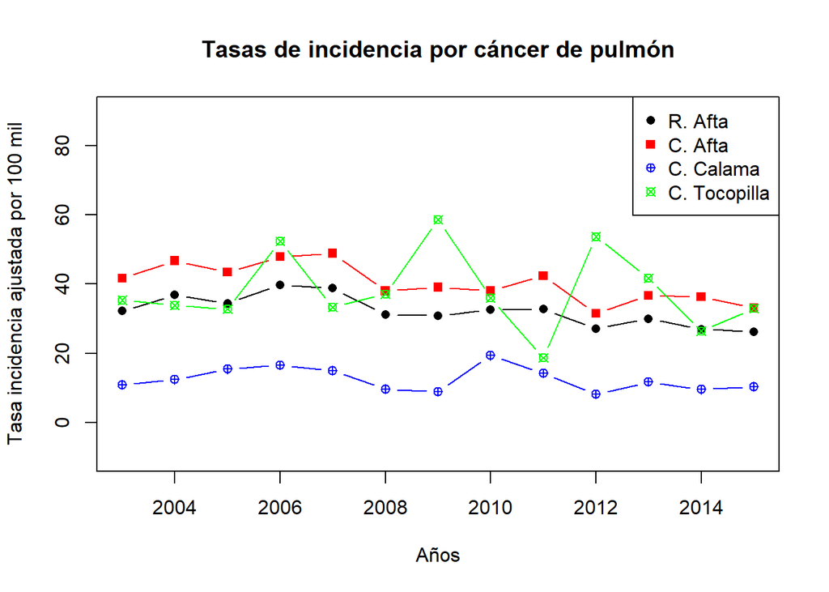